# Filter sites and operation

Alain Danet

11 March, 2022

```r
op_protocol %>%
  filter(is.na(date), !is.na(month))
```

```
#> # A tibble: 7,339 x 12
#>    siteid op_id   date    year month quarter protocol       protocol_detail
#>    <chr>  <chr>   <date> <dbl> <dbl>   <dbl> <chr>          <chr>
#>  1 S10203 ltm2046 NA      1993     7       3 Electrofishing Electrofishing
#>  2 S10203 ltm2047 NA      1994     7       3 Electrofishing Electrofishing
#>  3 S10203 ltm2048 NA      1995     7       3 Electrofishing Electrofishing
#>  4 S10203 ltm2049 NA      1996     7       3 Electrofishing Electrofishing
#>  5 S10203 ltm2050 NA      1997     7       3 Electrofishing Electrofishing
#>  6 S10203 ltm2051 NA      1998     7       3 Electrofishing Electrofishing
#>  7 S10203 ltm2052 NA      1999     7       3 Electrofishing Electrofishing
#>  8 S10203 ltm2053 NA      2000     6       2 Electrofishing Electrofishing
#>  9 S10203 ltm2054 NA      2001     7       3 Electrofishing Electrofishing
#> 10 S10203 ltm2055 NA      2002     7       3 Electrofishing Electrofishing
#> # ... with 7,329 more rows, and 4 more variables: sampledlength_m <dbl>,
#> #   unitabundance <chr>, watertemp_c <dbl>, unitbiomass <chr>
```

```r
op_protocol %>%
  filter(is.na(month), is.na(quarter))
```

```
#> # A tibble: 586 x 12
#>    siteid op_id  date    year month quarter protocol             protocol_detail
#>    <chr>  <chr>  <date> <dbl> <dbl>   <dbl> <chr>                <chr>
#>  1 S10088 mwr154 NA      2002    NA      NA Electrofishing       Electrofishing~
#>  2 S10088 mwr155 NA      2006    NA      NA Electrofishing       Electrofishing~
#>  3 S10088 mwr156 NA      2010    NA      NA Electrofishing       Electrofishing~
#>  4 S10088 mwr157 NA      2013    NA      NA Electrofishing       Electrofishing~
#>  5 S10088 mwr158 NA      2016    NA      NA Electrofishing       Electrofishing~
#>  6 S10088 mwr159 NA      2017    NA      NA Electrofishing       Electrofishing~
#>  7 S10088 mwr160 NA      2018    NA      NA Electrofishing       Electrofishing~
#>  8 S10446 and41  NA      2008    NA      NA Electrofishing_and_~ Electrofishing~
#>  9 S10446 and42  NA      2009    NA      NA Electrofishing_and_~ Electrofishing~
#> 10 S10446 and43  NA      2009    NA      NA Electrofishing_and_~ Electrofishing~
#> # ... with 576 more rows, and 4 more variables: sampledlength_m <dbl>,
#> #   unitabundance <chr>, watertemp_c <dbl>, unitbiomass <chr>
```

```r
test_filter <- filter_op(
      op_protocol = op_protocol,
      selected_protocol = NULL,
      nb_sampling = 5,
      extent_month = 1.5,
      return_no_filtered = TRUE,
      convert_month_to_date = TRUE
      )
```

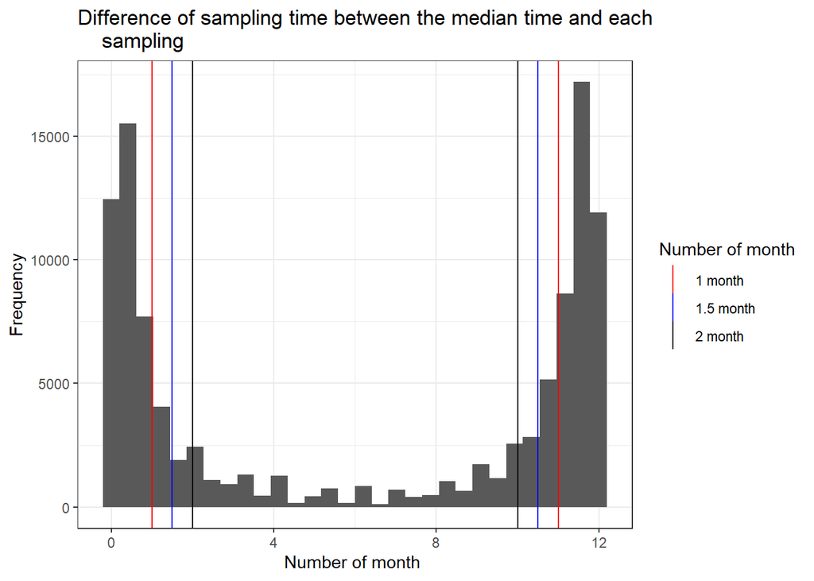

```r
ti <- tibble(x = c(1,2))
test_filter %>%
  ggplot(aes(x = (month_duration %% 12))) +
  geom_histogram() +
  geom_vline(data = ti, aes(xintercept = c(12 - 2, 2), color = "2 month")) +
  geom_vline(data = ti, aes(xintercept = c(12 - 1, 1), color = "1 month")) +
  geom_vline(data = ti, aes(xintercept = c(12 - 1.5, 1.5), color = "1.5 month")) +
  scale_color_manual(name = "Number of month",
    values = c(
      "1 month" = "red",
      "1.5 month" = "blue",
      "2 month" = "black"
    )) +
  labs(x = "Number of month ",
    title = "Difference of sampling time between the median time and each
    sampling",
    y = "Frequency")
```

# Summary of analysis

```r
tar_load(filtered_op_protocol)
tar_load(filtered_dataset)
```

```r
skim(filtered_dataset$site_quali)
```

Data summary

| Name | filtered_dataset$site_qua… |
| --- | --- |
| Number of rows | 5516 |
| Number of columns | 5 |
| _______________________ |  |
| Column type frequency: |  |
| character | 5 |
| ________________________ |  |
| Group variables | None |

**Variable type: character**

| skim_variable | n_missing | complete_rate | min | max | empty | n_unique | whitespace |
| --- | --- | --- | --- | --- | --- | --- | --- |
| siteid | 0 | 1.00 | 2 | 6 | 0 | 5516 | 0 |
| protocol | 0 | 1.00 | 7 | 29 | 0 | 15 | 0 |
| protocol_detail | 0 | 1.00 | 7 | 29 | 0 | 14 | 0 |
| unitbiomass | 4006 | 0.27 | 1 | 9 | 0 | 4 | 0 |
| unitabundance | 0 | 1.00 | 4 | 12 | 0 | 4 | 0 |

```r
tabyl_df(filtered_dataset$site_quali, "protocol") %>%
  kable()
```

| protocol | n | percent |
| --- | --- | --- |
| Electrofishing_backpack | 2602 | 47.2% |
| Electrofishing | 1758 | 31.9% |
| Electrofishing_partialsection | 612 | 11.1% |
| Electrofishing_wholesection | 343 | 6.2% |
| Electrofishing_boat | 82 | 1.5% |
| Electrofishing_and_netting | 34 | 0.6% |
| Seining | 30 | 0.5% |
| RotenoneLockchamber | 20 | 0.4% |
| Trapnetting | 12 | 0.2% |
| Gillnetting | 8 | 0.1% |
| Trapping | 6 | 0.1% |
| Seining_and_gillnetting | 5 | 0.1% |
| Trawling | 2 | 0.0% |
| Electrofishing_shorebased | 1 | 0.0% |
| Netting | 1 | 0.0% |
| Total | 5516 | 100.0% |

```r
tabyl_df(filtered_dataset$site_quali, "unitabundance") %>%
  kable()
```

| unitabundance | n | percent |
| --- | --- | --- |
| Ind.100m2 | 3666 | 66.5% |
| Count | 1822 | 33.0% |
| CPUE | 24 | 0.4% |
| Leslie_index | 4 | 0.1% |
| Total | 5516 | 100.0% |

- No much site in South America and Africa

```r
loc <- filtered_dataset$location %>%
  left_join(filtered_dataset$site_quali, by = "siteid") %>%
  st_as_sf(coords = c("longitude", "latitude"),
  crs = 4326)
```

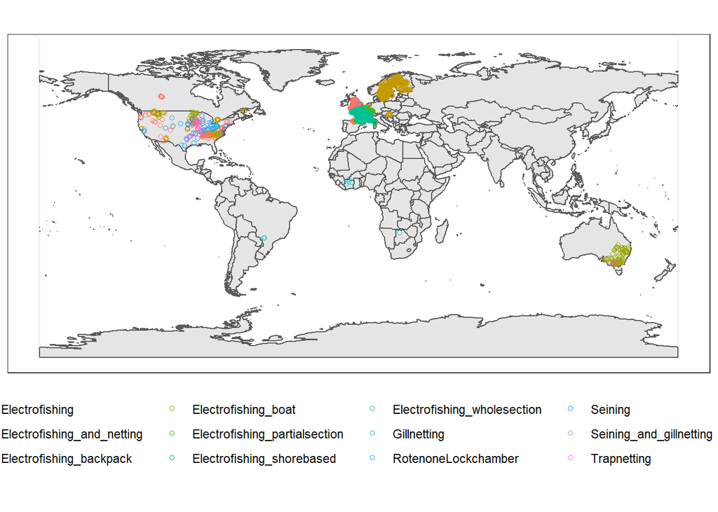

```r
world <- ne_countries(scale = "medium", returnclass = "sf")
ggplot(data = world) +
    geom_sf() +
    geom_sf(data = loc, aes(color = protocol), shape = 1) +
    theme(legend.position = "bottom")
```

```r
unique(loc$main_bas) %>% length
```

```
#> [1] 308
```

```r
unique(loc$waterbody) %>% length
```

```
#> [1] 2560
```

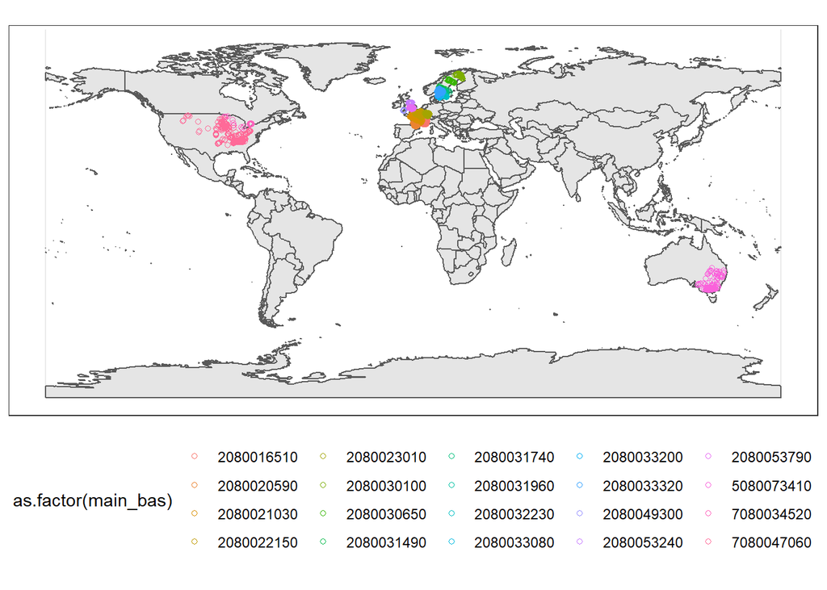

```r
ti <- table(as.factor(loc$main_bas)) %>%
  enframe() %>%
  arrange(desc(value))

ggplot(data = world) +
    geom_sf() +
    geom_sf(data = filter(loc, main_bas %in% ti$name[1:20]),
      aes(color = as.factor(main_bas)), shape = 1) +
    theme(legend.position = "bottom")
```

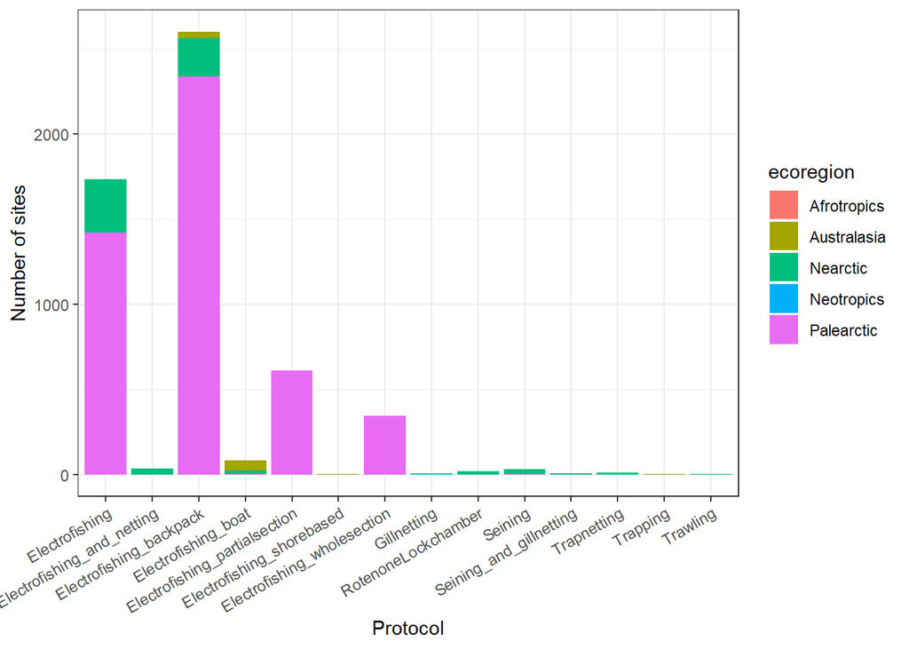

```r
loc %>%
  ggplot(aes(x = protocol, fill = ecoregion)) +
  geom_bar() +
  labs(x = "Protocol", y = "Number of sites") +
  theme(axis.text.x = element_text(angle = 30, hjust = 1))
```

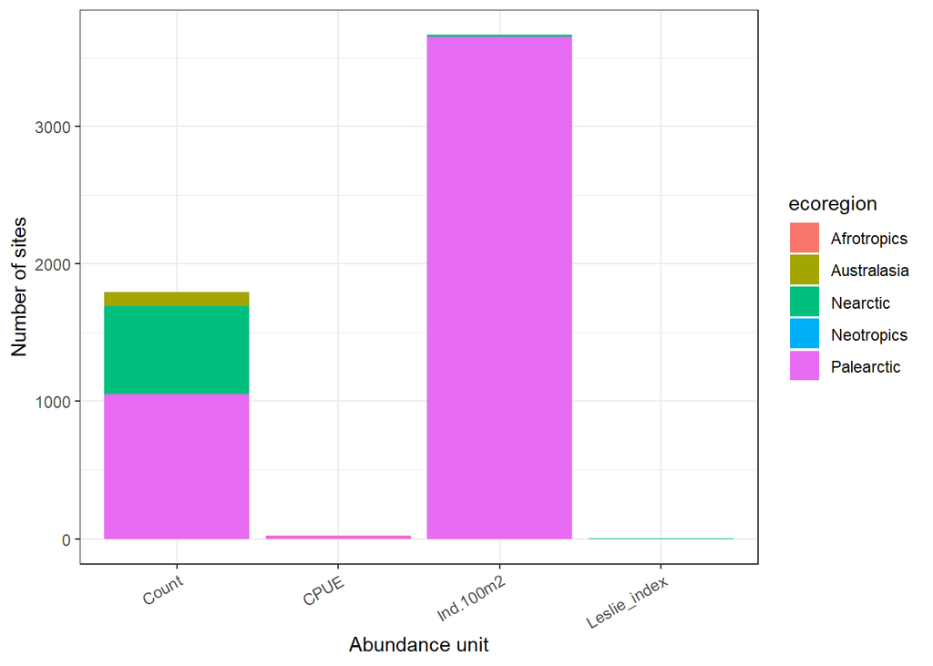

```r
loc %>%
  ggplot(aes(x = unitabundance, fill = ecoregion)) +
  geom_bar() +
  labs(x = "Abundance unit", y = "Number of sites") +
  theme(axis.text.x = element_text(angle = 30, hjust = 1))
```

```r
site_year <- filtered_dataset$site_quanti %>%
  filter(variable == "year") %>%
  left_join(filtered_dataset$location, by = "siteid") %>%
  mutate(
    span = max - min + 1,
    completeness = n / (span),
    cat_span = cut(span, c(0, 10, 20, 30, 40, 70), right = TRUE,
      include.lowest = TRUE
    ),
    cat_completeness = cut(
      completeness, c(0, .1, .25, .5, .75, 1), right = TRUE,
      include.lowest = TRUE
    )
    )
```

```r
map_dfr(c("span", "completeness", "min", "median", "max", "n"),
  ~tibble(
    variable = .x,
    median = median(site_year[[.x]]))
)
```

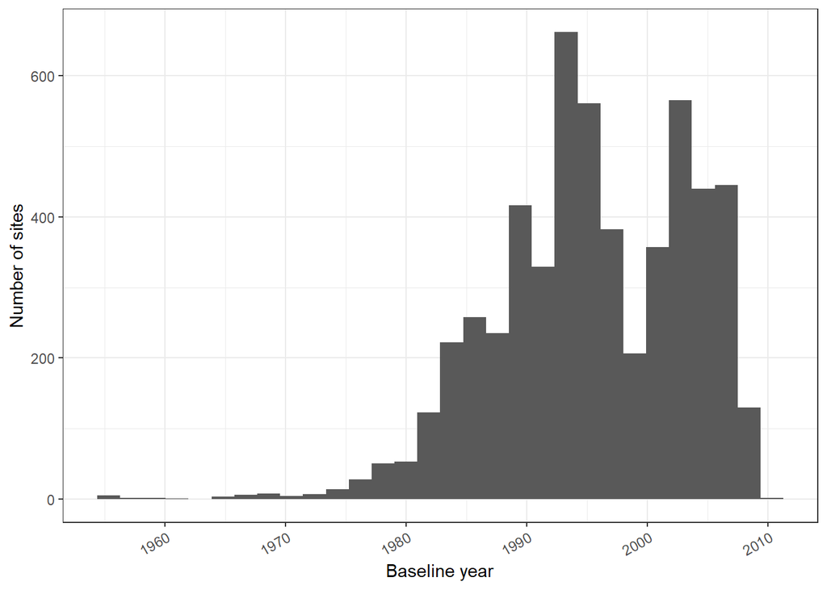

```r
site_year %>%
  ggplot(aes(x = min)) +
  geom_histogram() +
  labs(x = "Baseline year", y = "Number of sites") +
  theme(axis.text.x = element_text(angle = 30, hjust = 1))
```

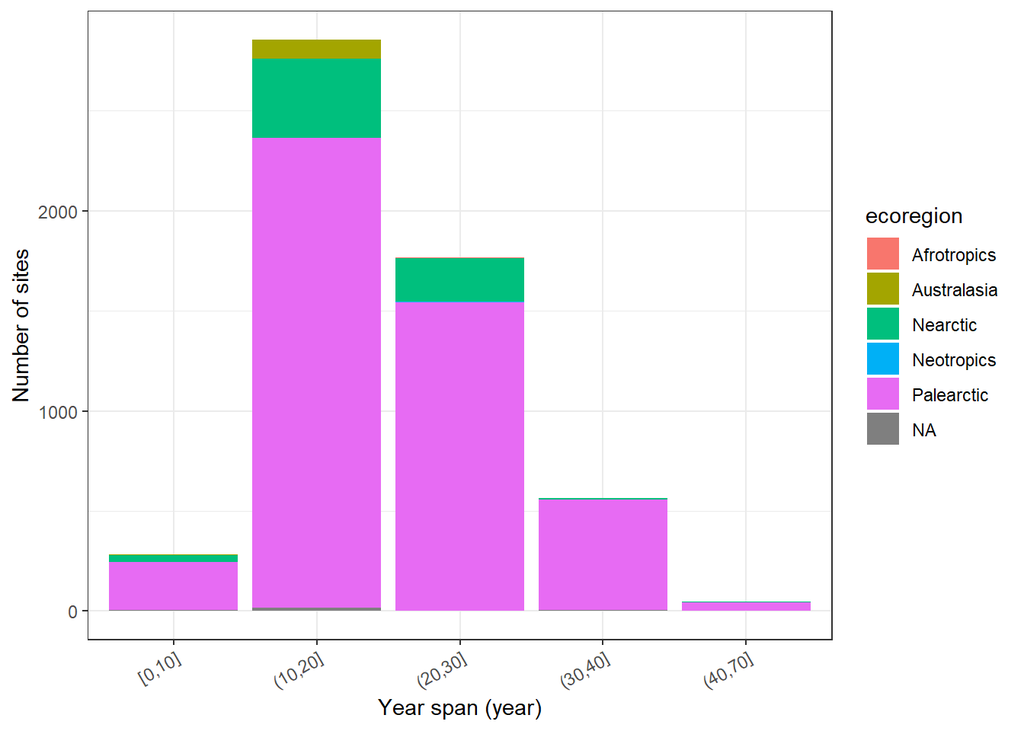

```r
site_year %>%
  ggplot(aes(x = cat_span, fill = ecoregion)) +
  geom_bar() +
  labs(x = "Year span (year)", y = "Number of sites") +
  theme(axis.text.x = element_text(angle = 30, hjust = 1))
```

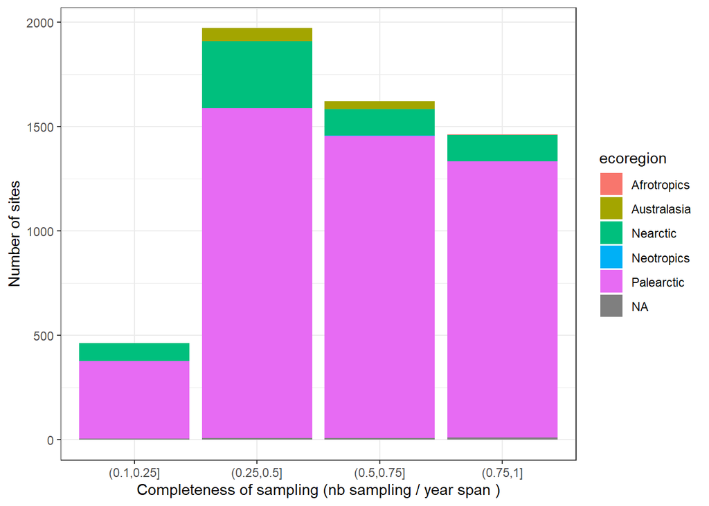

```r
site_year %>%
  ggplot(aes(x = cat_completeness, fill = ecoregion)) +
  geom_bar() +
  labs(
    x = "Completeness of sampling (nb sampling / year span )",
    y = "Number of sites"
  )
```

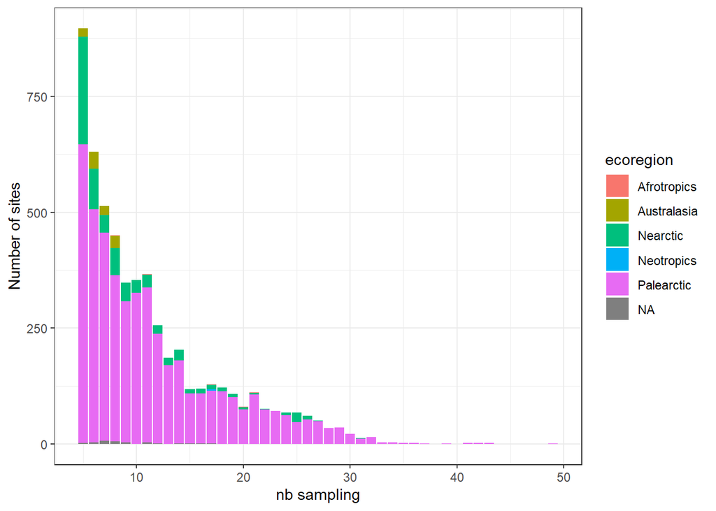

```r
site_year %>%
  ggplot(aes(x = n, fill = ecoregion)) +
  geom_bar() +
  labs(
    x = "nb sampling",
    y = "Number of sites"
  )
```

# Diversity

```r
tar_load(c(chao_hillnb, hillebrand, filtered_dataset))
```

```r
var_chao <- c("chao_richness", "chao_shannon", "chao_simpson")
chao_summary <- map_dfr(chao_hillnb[, var_chao],
  ~summary_distribution(.x, na.rm = TRUE), .id = "variable"
  )

chao_summary %>%
  kable()
```

| variable | min | 1st_quart | median | 2nd_quart | max | mean | sd | n | n_na | frac_na |
| --- | --- | --- | --- | --- | --- | --- | --- | --- | --- | --- |
| chao_richness | 1 | 1.938 | 3.1365 | 6.440 | 85.713 | 5.122615 | 5.447458 | 62174 | 0 | 0 |
| chao_shannon | 0 | 1.352 | 2.1300 | 3.626 | 33.633 | 2.792094 | 2.592941 | 62174 | 0 | 0 |
| chao_simpson | 0 | 1.196 | 1.7950 | 2.890 | 40.000 | 2.230624 | 1.917650 | 62174 | 0 | 0 |

```
#> Note: Using an external vector in selections is ambiguous.
#> i Use `all_of(var_chao)` instead of `var_chao` to silence this message.
#> i See <https://tidyselect.r-lib.org/reference/faq-external-vector.html>.
```

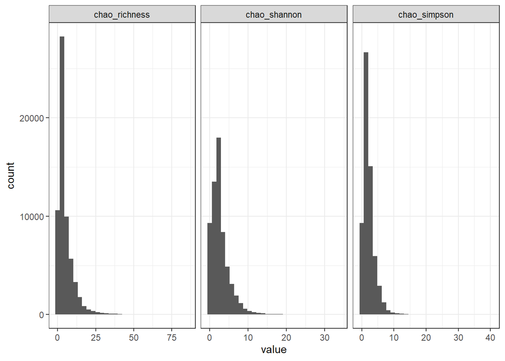

```r
chao_hillnb[, var_chao] %>%
  pivot_longer(., cols = c(var_chao)) %>%
  ggplot(aes(x = value)) +
  geom_histogram() +
  facet_grid(cols = vars(name), scales = "free_x")
```

- Chao methods on abundance density seems to fail
  - Update: fixed

```r
stopifnot(all(chao_summary$n_na == 0))
```

- However, chao shannon is NA when all abundances are equal
  - When all abundances are equal and since hill numbers are computed with the natural logarythm, shannon should be equal to ln($D^0$), $D^O$ being the species richness
  - Let’s replace equal abundances NA’s shannon by ln(chao richness)

```r
chao_hillnb %>%
  filter(is.na(chao_shannon))

mask_na <- chao_hillnb[is.na(chao_hillnb$chao_shannon), ]$op_id
ti <- filtered_dataset$measurement %>%
  filter(op_id == na.omit(mask_na)[4])
ti <- filtered_dataset$measurement %>%
  group_by(op_id) %>%
  mutate(abundance = round(adjust_abun_chao(abundance))) %>%
  ungroup() %>%
  nest_by(op_id)
tid <- map(ti$data, "abundance")
names(tid) <- ti$op_id
mesure <- furrr::future_map_dfr(
  tid, ~c(n_unique = length(unique(.x))),
    .id = "op_id"
    )
mesure[is.na(chao_hillnb$chao_shannon), ]$n_unique == 1


vegan::diversity(round(adjust_abun_chao(ti$abundance)))
invChat.Ind_c(round(adjust_abun_chao(ti$abundance)), C = .985, conf = NULL)

shannon_na_unique_abun <- filtered_dataset$measurement %>%
  filter(op_id %in% na.omit(mask_na)) %>%
  group_by(op_id) %>%
  mutate(abun_adjusted = round(adjust_abun_chao(abundance))) %>%
  summarise(
    n_unique = length(unique(abundance)),
    n_ajust = length(unique(abun_adjusted))
  )
```

- Same thing with Chao, simpson should be 0 when one species only.

```r
chao_hillnb %>%
  filter(is.na(chao_simpson))


mask_na <- chao_hillnb[is.na(chao_hillnb$chao_simpson), ]$op_id
ti <- filtered_dataset$measurement %>%
  filter(op_id == na.omit(mask_na)[4])


vegan::diversity(round(adjust_abun_chao(ti$abundance)), index = "simpson")
invChat.Ind_c(round(adjust_abun_chao(ti$abundance)), C = .985, conf = NULL)

filtered_dataset$measurement %>%
  filter(op_id %in% na.omit(mask_na))

simpson_na_unique_abun <- filtered_dataset$measurement %>%
  filter(op_id %in% na.omit(mask_na)) %>%
  group_by(op_id) %>%
  mutate(abun_adjusted = round(adjust_abun_chao(abundance))) %>%
  summarise(
    n = n(),
    n_unique = length(unique(abundance)),
    n_ajust = length(unique(abun_adjusted))
  )
```

```r
chao_hillnb %>%
  filter(chao_shannon == c("-Inf", "Inf"))
chao_hillnb[42923, ]

mask_minus_inf <- chao_hillnb[chao_hillnb$chao_shannon == "-Inf", ]$op_id
ti <- filtered_dataset$measurement %>%
  filter(op_id == na.omit(mask_minus_inf)[1])

rec <- adjust_abun_chao(ti$abundance)
invChat.Ind_c(ti$abundance, C = .985, conf = NULL)
invChat.Ind_c(as.integer(round(ti$abundance)), C = .985, conf = NULL)
invChat.Ind_c(rec, C = .985, conf = NULL)
invChat.Ind_c(as.integer(round(rec)), C = .985, conf = NULL)
Dqhat.Ind


mask_inf <- chao_hillnb[chao_hillnb$chao_shannon == "Inf", ]$op_id

ti <- filtered_dataset$measurement %>%
  filter(op_id %in% na.omit(mask_inf)[2])

invChat.Ind_c(ti$abundance %>% round, C = .985, conf = NULL)
invChat.Ind_c(ti$abundance, C = .985, conf = NULL)
vegan::diversity(ti$abundance)
```

```r
chao_hillnb %>%
  filter(chao_shannon == "Inf")
any(chao_hillnb$chao_shannon == "Inf" & chao_hillnb$method == "interpolated")
any(chao_hillnb$chao_shannon == "Inf" & chao_hillnb$method != "interpolated")

ti <- filtered_dataset$measurement %>%
  filter(op_id == "nfp136")

chao_hillnb[4230, ]
invChat.Ind_c((ti$abundance), C = .985, conf = NULL)
invChat.Ind_c((ti$abundance) * 100, C = .985, conf = NULL)
```

- On va multiplier les densité d’abondances par le minimum pour que l’abondance minimal soit de 1 pour les calculs de chao
  - ça va pas affecter négativement le chao car il n’est pas basé sur l’effort d’échantillonnage
  - ça fait sens
  - ça augmente le nombre de singleton mais au augmentant au minimum le nombre d’individus total dans la communauté

# Spatial assessment

```r
tar_load(spde)
plot(spde)
```

# Environment

## Water and air temperature

```r
tar_load(c(at_mv_avg, wt_mv_avg))

awt <- full_join(at_mv_avg, wt_mv_avg, by = c("siteid", "year"))
skim(awt)
```

Data summary

| Name | awt |
| --- | --- |
| Number of rows | 295449 |
| Number of columns | 4 |
| _______________________ |  |
| Column type frequency: |  |
| character | 1 |
| numeric | 3 |
| ________________________ |  |
| Group variables | None |

**Variable type: character**

| skim_variable | n_missing | complete_rate | min | max | empty | n_unique | whitespace |
| --- | --- | --- | --- | --- | --- | --- | --- |
| siteid | 0 | 1 | 2 | 6 | 0 | 5488 | 0 |

**Variable type: numeric**

| skim_variable | n_missing | complete_rate | mean | sd | p0 | p25 | p50 | p75 | p100 | hist |
| --- | --- | --- | --- | --- | --- | --- | --- | --- | --- | --- |
| year | 0 | 1.00 | 1989.55 | 15.58 | 1960.00 | 1976.00 | 1990.00 | 2003.00 | 2016.00 | ▆▇▇▇▇ |
| tmp_a_ana | 130809 | 0.56 | 8.73 | 3.73 | -1.80 | 6.56 | 8.85 | 11.00 | 28.02 | ▂▇▆▁▁ |
| tmp_w_ama | 50894 | 0.83 | 9.97 | 3.78 | 1.03 | 7.39 | 9.64 | 12.09 | 37.91 | ▅▇▁▁▁ |

```r
wt_site_avg <- wt_mv_avg %>%
  group_by(siteid) %>%
  summarise(avg_w_tmp = mean(tmp_w_ama))
```

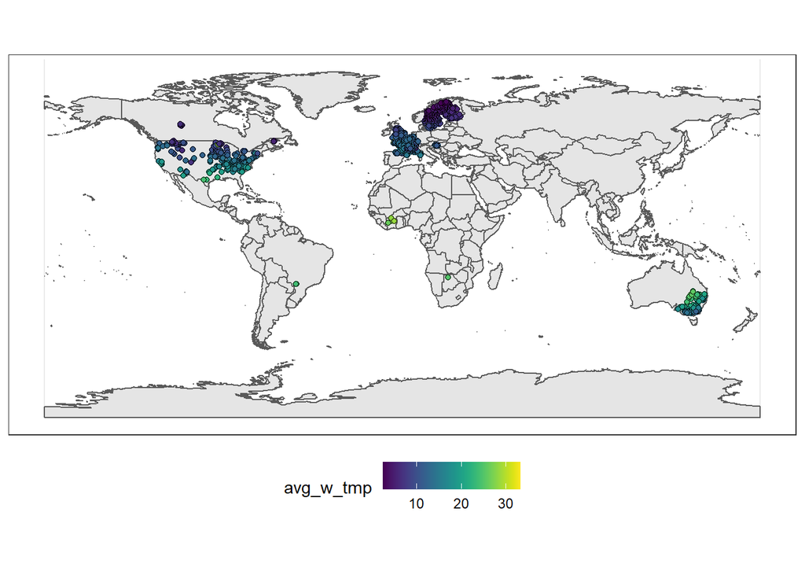

```r
loc_wt <- loc %>%
  left_join(wt_site_avg, by = "siteid")

ggplot(data = world) + geom_sf() +
  geom_sf(data = loc_wt, aes(fill = avg_w_tmp), shape = 21) +
  scale_fill_viridis() +
  theme(legend.position = "bottom")
```

- Check if NA:

```r
tar_load(analysis_dataset)
skim(analysis_dataset)
```

Data summary

| Name | analysis_dataset |
| --- | --- |
| Number of rows | 62174 |
| Number of columns | 57 |
| _______________________ |  |
| Column type frequency: |  |
| character | 11 |
| factor | 1 |
| numeric | 45 |
| ________________________ |  |
| Group variables | None |

**Variable type: character**

| skim_variable | n_missing | complete_rate | min | max | empty | n_unique | whitespace |
| --- | --- | --- | --- | --- | --- | --- | --- |
| op_id | 0 | 1.00 | 4 | 8 | 0 | 62174 | 0 |
| siteid | 0 | 1.00 | 2 | 6 | 0 | 5516 | 0 |
| protocol | 0 | 1.00 | 7 | 29 | 0 | 15 | 0 |
| protocol_detail | 0 | 1.00 | 7 | 29 | 0 | 14 | 0 |
| unitbiomass | 45609 | 0.27 | 1 | 9 | 0 | 4 | 0 |
| unitabundance | 0 | 1.00 | 4 | 12 | 0 | 4 | 0 |
| province | 2384 | 0.96 | 3 | 28 | 0 | 632 | 0 |
| waterbody | 2384 | 0.96 | 2 | 31 | 0 | 2559 | 0 |
| country | 251 | 1.00 | 3 | 3 | 0 | 14 | 0 |
| region | 2384 | 0.96 | 3 | 26 | 0 | 109 | 0 |
| ecoregion | 251 | 1.00 | 8 | 11 | 0 | 5 | 0 |

**Variable type: factor**

| skim_variable | n_missing | complete_rate | ordered | n_unique | top_counts |
| --- | --- | --- | --- | --- | --- |
| main_bas | 251 | 1 | FALSE | 308 | 708: 2941, 208: 2648, 208: 2304, 208: 1636 |

**Variable type: numeric**

| skim_variable | n_missing | complete_rate | mean | sd | p0 | p25 | p50 | p75 | p100 | hist |
| --- | --- | --- | --- | --- | --- | --- | --- | --- | --- | --- |
| species_nb | 0 | 1.00 | 5.60 | 5.92 | 1.00 | 2.00 | 3.00 | 7.00 | 72.00 | ▇▁▁▁▁ |
| total_abundance | 0 | 1.00 | 228.03 | 1125.99 | 0.01 | 19.10 | 56.00 | 181.00 | 109088.00 | ▇▁▁▁▁ |
| log_total_abundance | 0 | 1.00 | 4.04 | 1.71 | -4.61 | 2.95 | 4.03 | 5.20 | 11.60 | ▁▁▇▃▁ |
| log_species_nb | 0 | 1.00 | 1.33 | 0.87 | 0.00 | 0.69 | 1.10 | 1.95 | 4.28 | ▇▇▅▂▁ |
| year | 0 | 1.00 | 2004.92 | 8.56 | 1955.00 | 1999.00 | 2006.00 | 2012.00 | 2019.00 | ▁▁▂▇▇ |
| latitude | 251 | 1.00 | 53.02 | 12.30 | -37.47 | 48.07 | 55.81 | 59.42 | 68.48 | ▁▁▁▂▇ |
| longitude | 251 | 1.00 | 1.37 | 34.09 | -123.07 | -1.25 | 11.91 | 15.38 | 151.92 | ▁▁▇▁▁ |
| chao_richness | 0 | 1.00 | 5.12 | 5.45 | 1.00 | 1.94 | 3.14 | 6.44 | 85.71 | ▇▁▁▁▁ |
| chao_shannon | 0 | 1.00 | 2.79 | 2.59 | 0.00 | 1.35 | 2.13 | 3.63 | 33.63 | ▇▁▁▁▁ |
| chao_simpson | 0 | 1.00 | 2.23 | 1.92 | 0.00 | 1.20 | 1.79 | 2.89 | 40.00 | ▇▁▁▁▁ |
| chao_evenness | 0 | 1.00 | 1.93 | 1.54 | 0.00 | 1.47 | 2.06 | 2.47 | 38.25 | ▇▁▁▁▁ |
| hillebrand | 0 | 1.00 | 0.68 | 0.33 | 0.00 | 0.42 | 0.79 | 0.99 | 1.00 | ▂▂▂▂▇ |
| total | 0 | 1.00 | 0.24 | 0.20 | 0.00 | 0.00 | 0.25 | 0.38 | 1.00 | ▇▆▃▁▁ |
| appearance | 0 | 1.00 | 0.14 | 0.16 | 0.00 | 0.00 | 0.10 | 0.24 | 0.92 | ▇▃▁▁▁ |
| disappearance | 0 | 1.00 | 0.11 | 0.14 | 0.00 | 0.00 | 0.00 | 0.17 | 0.86 | ▇▂▁▁▁ |
| jaccard | 0 | 1.00 | 0.65 | 0.27 | 0.00 | 0.50 | 0.67 | 1.00 | 1.00 | ▁▃▇▆▇ |
| horn | 0 | 1.00 | 0.76 | 0.22 | 0.00 | 0.67 | 0.80 | 1.00 | 1.00 | ▁▁▂▅▇ |
| chao | 0 | 1.00 | 0.86 | 0.26 | 0.00 | 0.83 | 1.00 | 1.00 | 1.00 | ▁▁▁▁▇ |
| total_abundance_int | 0 | 1.00 | 227.72 | 1126.03 | 0.00 | 19.00 | 56.00 | 181.00 | 109088.00 | ▇▁▁▁▁ |
| shannon | 0 | 1.00 | 0.86 | 0.65 | 0.00 | 0.34 | 0.76 | 1.29 | 3.54 | ▇▆▃▁▁ |
| simpson | 0 | 1.00 | 0.42 | 0.28 | 0.00 | 0.17 | 0.48 | 0.66 | 0.96 | ▇▅▇▇▃ |
| inv_simpson | 0 | 1.00 | 2.39 | 1.72 | 1.00 | 1.21 | 1.91 | 2.90 | 23.24 | ▇▁▁▁▁ |
| evenness | 0 | 1.00 | 0.54 | 0.30 | 0.00 | 0.33 | 0.63 | 0.77 | 1.00 | ▅▂▅▇▅ |
| jaccard_dis | 0 | 1.00 | 0.35 | 0.27 | 0.00 | 0.00 | 0.33 | 0.50 | 1.00 | ▇▆▆▃▁ |
| nestedness | 0 | 1.00 | 0.19 | 0.22 | 0.00 | 0.00 | 0.10 | 0.33 | 0.96 | ▇▂▂▁▁ |
| turnover | 0 | 1.00 | 0.16 | 0.25 | 0.00 | 0.00 | 0.00 | 0.33 | 1.00 | ▇▂▁▁▁ |
| dist_up_km | 7548 | 0.88 | 80.14 | 194.24 | 2.70 | 13.10 | 25.40 | 58.20 | 2798.30 | ▇▁▁▁▁ |
| ord_stra | 7548 | 0.88 | 2.48 | 1.46 | 1.00 | 1.00 | 2.00 | 3.00 | 9.00 | ▇▅▁▁▁ |
| dis_m3_pyr | 7548 | 0.88 | 56.22 | 336.69 | 0.03 | 0.55 | 1.61 | 7.30 | 7830.69 | ▇▁▁▁▁ |
| ele_mt_cav | 7548 | 0.88 | 228.87 | 260.96 | -1.00 | 84.00 | 158.00 | 265.00 | 2531.00 | ▇▁▁▁▁ |
| tmp_dc_cyr | 7548 | 0.88 | 76.18 | 39.01 | -27.00 | 57.00 | 77.00 | 101.00 | 274.00 | ▃▇▆▁▁ |
| pac_pc_cse | 7548 | 0.88 | 13.75 | 29.29 | 0.00 | 0.00 | 0.00 | 6.00 | 100.00 | ▇▁▁▁▁ |
| urb_pc_cse | 7548 | 0.88 | 7.74 | 20.72 | 0.00 | 0.00 | 0.00 | 0.00 | 100.00 | ▇▁▁▁▁ |
| hft_ix_c09 | 7548 | 0.88 | 158.25 | 107.17 | 2.00 | 72.00 | 132.00 | 226.00 | 456.00 | ▇▇▃▂▁ |
| scaled_dist_up_km | 7548 | 0.88 | 0.00 | 1.00 | -0.40 | -0.35 | -0.28 | -0.11 | 13.99 | ▇▁▁▁▁ |
| log_dist_up_km | 7548 | 0.88 | 3.44 | 1.18 | 0.99 | 2.57 | 3.23 | 4.06 | 7.94 | ▃▇▃▁▁ |
| scaled_tmp_dc_cyr | 7548 | 0.88 | 0.00 | 1.00 | -2.65 | -0.49 | 0.02 | 0.64 | 5.07 | ▃▇▆▁▁ |
| tmp_c_cyr | 7548 | 0.88 | 7.62 | 3.90 | -2.70 | 5.70 | 7.70 | 10.10 | 27.40 | ▃▇▆▁▁ |
| scaled_tmp_c_cyr | 7548 | 0.88 | 0.00 | 1.00 | -2.65 | -0.49 | 0.02 | 0.64 | 5.07 | ▃▇▆▁▁ |
| first_year | 0 | 1.00 | 1993.70 | 8.17 | 1955.00 | 1989.00 | 1994.00 | 2000.00 | 2010.00 | ▁▁▃▇▅ |
| last_year | 0 | 1.00 | 2015.22 | 4.59 | 1980.00 | 2015.00 | 2017.00 | 2018.00 | 2019.00 | ▁▁▁▁▇ |
| span | 0 | 1.00 | 22.52 | 8.43 | 10.00 | 16.00 | 22.00 | 29.00 | 64.00 | ▇▇▂▁▁ |
| jaccard_scaled | 0 | 1.00 | 0.65 | 0.27 | 0.00 | 0.50 | 0.67 | 1.00 | 1.00 | ▁▃▇▆▇ |
| one | 0 | 1.00 | 1.00 | 0.00 | 1.00 | 1.00 | 1.00 | 1.00 | 1.00 | ▁▁▇▁▁ |
| year_nb | 0 | 1.00 | 11.22 | 8.66 | 0.00 | 4.00 | 10.00 | 17.00 | 63.00 | ▇▅▁▁▁ |

```r
na_tmp <- analysis_dataset %>%
  left_join(wt_mv_avg, by = c("siteid", "year")) %>%
  left_join(at_mv_avg, by = c("siteid", "year")) %>%
  select(siteid, year, tmp_w_ama, tmp_a_ana) %>%
  pivot_longer(
    cols = c(tmp_w_ama, tmp_a_ana),
    names_to = "variable", values_to = "tmp") %>%
  group_by(variable, year) %>%
  summarise(n_na = sum(is.na(tmp)), p_na = n_na / n(), .groups = "drop")
```

- Air temperature can be interesting to complete water temperature data:
  - between 2007 and 2016
  - `analysis_dataset %>% filter(variable == "tmp_a_ana")`

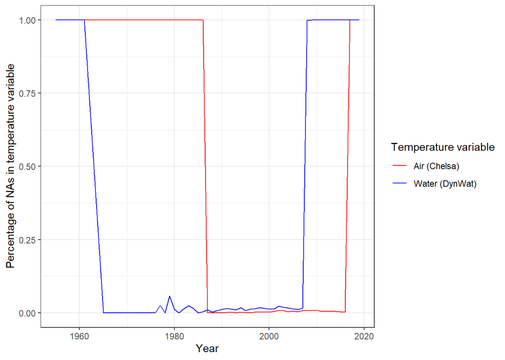

```r
na_tmp %>%
  ggplot(aes(y = p_na, x = year, color = variable)) +
  geom_line() +
  labs(y = "Percentage of NAs in temperature variable",
    x = "Year", color = "Temperature variable") +
  scale_color_manual(values = c("red", "blue"), labels = c("Air (Chelsa)", "Water (DynWat)"))
```

```r
ti <- analysis_dataset %>%
  left_join(wt_mv_avg, by = c("siteid", "year")) %>%
  left_join(at_mv_avg, by = c("siteid", "year")) %>%
  select(siteid, year, tmp_w_ama, tmp_a_ana) %>%
  skim_tee() %>%
  mutate(
    w_tmp_na = is.na(tmp_w_ama),
    a_tmp_na = is.na(tmp_a_ana),
    tmp_w_ama = ifelse( is.na(tmp_w_ama) & !is.na(tmp_a_ana),
      tmp_a_ana, tmp_w_ama)
  )
```

```
#> -- Data Summary ------------------------
#>                            Values
#> Name                       data
#> Number of rows             62174
#> Number of columns          4
#> _______________________
#> Column type frequency:
#>   character                1
#>   numeric                  3
#> ________________________
#> Group variables            None
#>
#> -- Variable type: character ----------------------------------------------------
#> # A tibble: 1 x 8
#>   skim_variable n_missing complete_rate   min   max empty n_unique whitespace
#> * <chr>             <int>         <dbl> <int> <int> <int>    <int>      <int>
#> 1 siteid                0             1     2     6     0     5516          0
#>
#> -- Variable type: numeric ------------------------------------------------------
#> # A tibble: 3 x 11
#>   skim_variable n_missing complete_rate    mean    sd      p0     p25     p50
#> * <chr>             <int>         <dbl>   <dbl> <dbl>   <dbl>   <dbl>   <dbl>
#> 1 year                  0         1     2005.    8.56 1955    1999    2006
#> 2 tmp_w_ama         26999         0.566    9.84  3.84    2.32    7.18    9.20
#> 3 tmp_a_ana          6020         0.903    8.37  3.83   -1.60    6.15    8.19
#>      p75   p100 hist
#> *  <dbl>  <dbl> <chr>
#> 1 2012   2019   ▁▁▂▇▇
#> 2   12.3   34.7 ▇▇▁▁▁
#> 3   11.0   27.4 ▃▇▆▁▁
```

```r
na_w_not_na_a <- ti %>%
  group_by(year) %>%
  summarise(w_tmp_na = sum(w_tmp_na) /n(), a_tmp_na = sum(a_tmp_na) / n()) %>%
  filter(w_tmp_na == 1 & a_tmp_na < .01)
ratio_data_na_w_no_na_a <-
  analysis_dataset[analysis_dataset$year %in% na_w_not_na_a$year, ] %>%
  nrow /
  nrow(analysis_dataset)
```

- NA period in water temperature but not in air temperature:
  - 32% of the data

## River atlas

```r
tar_load(riveratlas_site)
```

```r
# Elevation
colnames(riveratlas_site)[str_detect(colnames(riveratlas_site), "ele_")]
```

```
#> [1] "ele_mt_cav" "ele_mt_uav" "ele_mt_cmn" "ele_mt_cmx"
```

```r
# Slope
colnames(riveratlas_site)[str_detect(colnames(riveratlas_site), "slp_")]
```

```
#> [1] "slp_dg_cav" "slp_dg_uav"
```

```r
# Temperature
colnames(riveratlas_site)[str_detect(colnames(riveratlas_site), "tmp_")]
```

```
#>  [1] "tmp_dc_cyr" "tmp_dc_uyr" "tmp_dc_cmn" "tmp_dc_cmx" "tmp_dc_c01"
#>  [6] "tmp_dc_c02" "tmp_dc_c03" "tmp_dc_c04" "tmp_dc_c05" "tmp_dc_c06"
#> [11] "tmp_dc_c07" "tmp_dc_c08" "tmp_dc_c09" "tmp_dc_c10" "tmp_dc_c11"
#> [16] "tmp_dc_c12"
```

```r
# River position
colnames(riveratlas_site)[str_detect(colnames(riveratlas_site), "tmp_")]
```

```
#>  [1] "tmp_dc_cyr" "tmp_dc_uyr" "tmp_dc_cmn" "tmp_dc_cmx" "tmp_dc_c01"
#>  [6] "tmp_dc_c02" "tmp_dc_c03" "tmp_dc_c04" "tmp_dc_c05" "tmp_dc_c06"
#> [11] "tmp_dc_c07" "tmp_dc_c08" "tmp_dc_c09" "tmp_dc_c10" "tmp_dc_c11"
#> [16] "tmp_dc_c12"
```

```r
# River discharge
colnames(riveratlas_site)[str_detect(colnames(riveratlas_site), "dis_m3")]
```

```
#> [1] "dis_m3_pyr" "dis_m3_pmn" "dis_m3_pmx"
```

```r
colnames(riveratlas_site)[str_detect(colnames(riveratlas_site), "ria_")]
```

```
#> [1] "ria_ha_csu" "ria_ha_usu"
```

```r
# Human footprint
colnames(riveratlas_site)[str_detect(colnames(riveratlas_site), "hft_")]
```

```
#> [1] "hft_ix_c93" "hft_ix_u93" "hft_ix_c09" "hft_ix_u09"
```

```r
# Population density
colnames(riveratlas_site)[str_detect(colnames(riveratlas_site), "pnv_")]
```

```
#>  [1] "pnv_cl_cmj" "pnv_pc_c01" "pnv_pc_c02" "pnv_pc_c03" "pnv_pc_c04"
#>  [6] "pnv_pc_c05" "pnv_pc_c06" "pnv_pc_c07" "pnv_pc_c08" "pnv_pc_c09"
#> [11] "pnv_pc_c10" "pnv_pc_c11" "pnv_pc_c12" "pnv_pc_c13" "pnv_pc_c14"
#> [16] "pnv_pc_c15" "pnv_pc_u01" "pnv_pc_u02" "pnv_pc_u03" "pnv_pc_u04"
#> [21] "pnv_pc_u05" "pnv_pc_u06" "pnv_pc_u07" "pnv_pc_u08" "pnv_pc_u09"
#> [26] "pnv_pc_u10" "pnv_pc_u11" "pnv_pc_u12" "pnv_pc_u13" "pnv_pc_u14"
#> [31] "pnv_pc_u15"
```

```r
riveratlas_site <- riveratlas_site %>%
  mutate(across(starts_with("tmp_"), ~.x / 10))
```

```r
riv <- riveratlas_site %>%
  select(all_of(get_river_atlas_significant_var())) %>%
  st_drop_geometry()
```

```r
skim(riv)
```

Data summary

| Name | riv |
| --- | --- |
| Number of rows | 4916 |
| Number of columns | 8 |
| _______________________ |  |
| Column type frequency: |  |
| numeric | 8 |
| ________________________ |  |
| Group variables | None |

**Variable type: numeric**

| skim_variable | n_missing | complete_rate | mean | sd | p0 | p25 | p50 | p75 | p100 | hist |
| --- | --- | --- | --- | --- | --- | --- | --- | --- | --- | --- |
| Distance from source | 0 | 1 | 72.54 | 186.42 | 2.70 | 13.10 | 24.80 | 53.30 | 2798.30 | ▇▁▁▁▁ |
| Strahler order | 0 | 1 | 2.43 | 1.41 | 1.00 | 1.00 | 2.00 | 3.00 | 9.00 | ▇▅▁▁▁ |
| Average elevation (m) | 0 | 1 | 233.98 | 265.48 | -1.00 | 84.00 | 160.00 | 271.00 | 2531.00 | ▇▁▁▁▁ |
| Annual average of temperature (Â°C) | 0 | 1 | 8.05 | 3.76 | -2.70 | 6.10 | 8.40 | 10.20 | 27.40 | ▂▇▇▁▁ |
| Annual average of discharge (m3/s) | 0 | 1 | 45.06 | 308.48 | 0.03 | 0.55 | 1.54 | 6.17 | 7830.69 | ▇▁▁▁▁ |
| Protected area extent (%) | 0 | 1 | 15.12 | 30.82 | 0.00 | 0.00 | 0.00 | 7.00 | 100.00 | ▇▁▁▁▁ |
| Urban extent (%) | 0 | 1 | 9.28 | 22.71 | 0.00 | 0.00 | 0.00 | 0.00 | 100.00 | ▇▁▁▁▁ |
| Human footprint 2009 (index) | 0 | 1 | 169.08 | 111.71 | 2.00 | 77.00 | 142.00 | 250.00 | 456.00 | ▇▇▅▃▂ |

### Human footprint

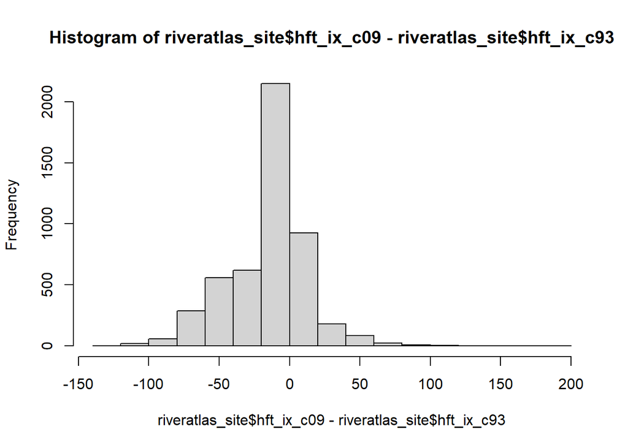

```r
hist(riveratlas_site$hft_ix_c09 - riveratlas_site$hft_ix_c93)
```

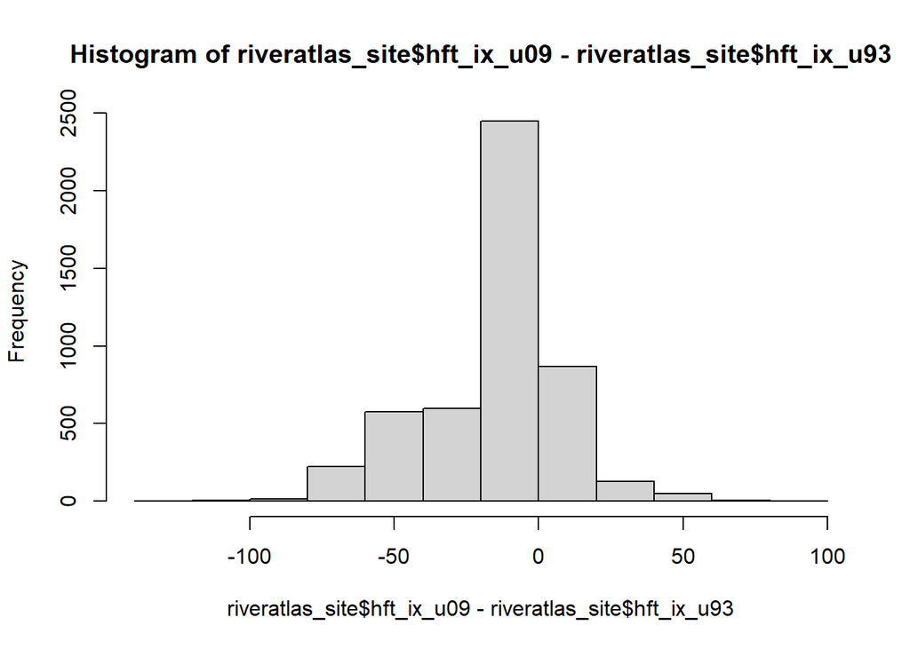

```r
hist(riveratlas_site$hft_ix_u09 - riveratlas_site$hft_ix_u93)
```

- Diff scaled no center:

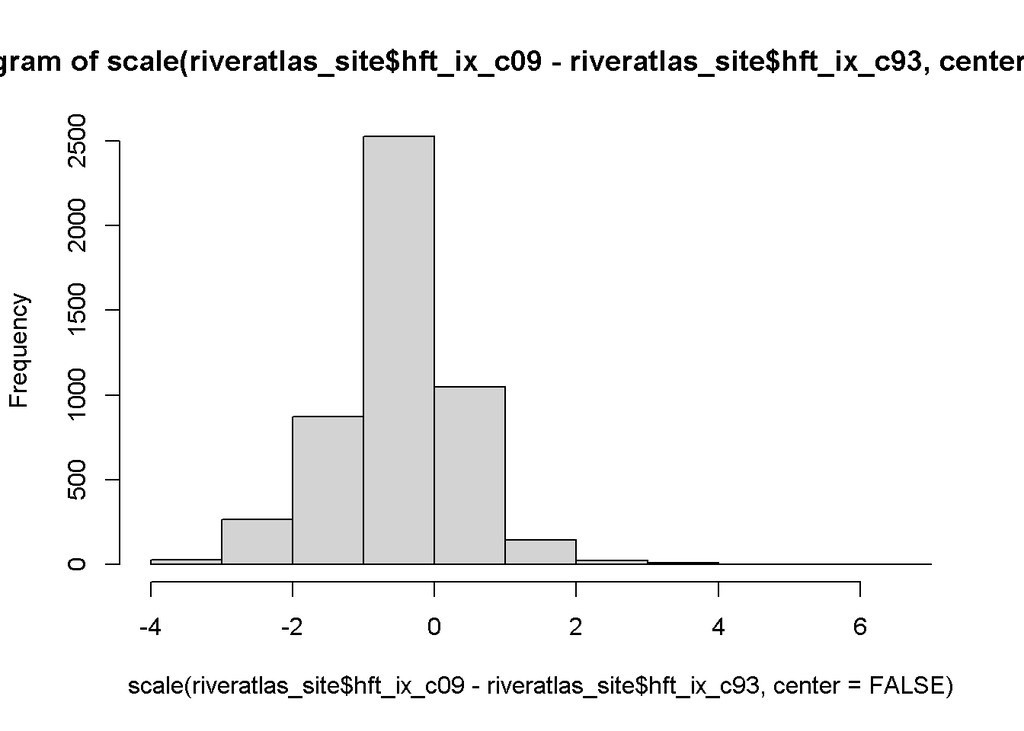

```r
hist(scale(riveratlas_site$hft_ix_c09 - riveratlas_site$hft_ix_c93, center =
    FALSE))
```

- Ratio and log ratio:

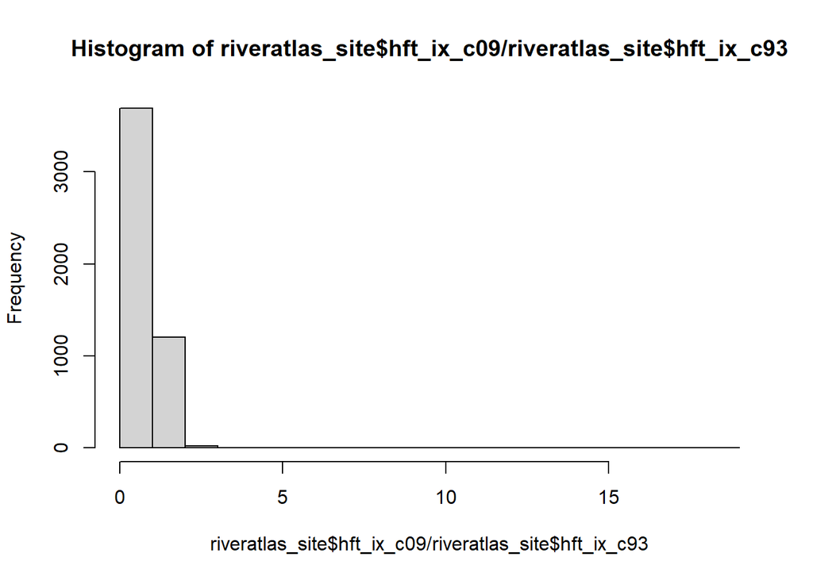

```r
hist(riveratlas_site$hft_ix_c09 / riveratlas_site$hft_ix_c93)
```

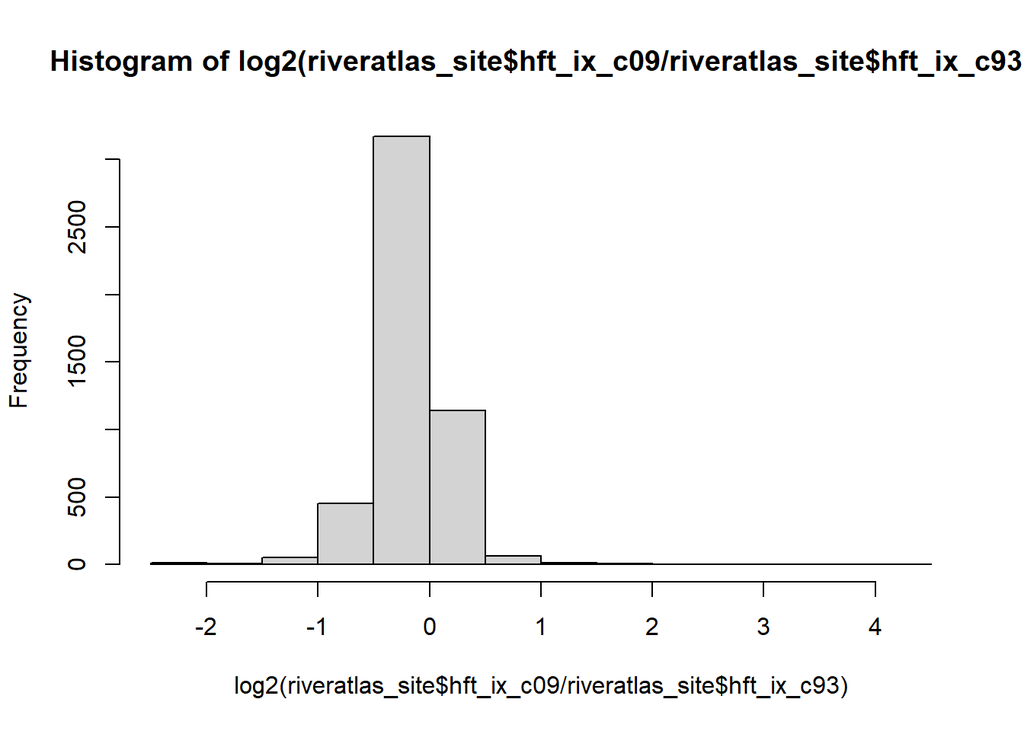

```r
hist(log2(riveratlas_site$hft_ix_c09 / riveratlas_site$hft_ix_c93))
```

```r
loc_hft <- loc %>%
  left_join(riveratlas_site %>%
      select(c("siteid", starts_with("hft_"))) %>%
      st_drop_geometry(),
    by = "siteid"
  )
skim_tee(st_drop_geometry(loc_hft))
```

```
#> -- Data Summary ------------------------
#>                            Values
#> Name                       data
#> Number of rows             5488
#> Number of columns          15
#> _______________________
#> Column type frequency:
#>   character                10
#>   numeric                  5
#> ________________________
#> Group variables            None
#>
#> -- Variable type: character ----------------------------------------------------
#> # A tibble: 10 x 8
#>    skim_variable   n_missing complete_rate   min   max empty n_unique whitespace
#>  * <chr>               <int>         <dbl> <int> <int> <int>    <int>      <int>
#>  1 siteid                  0         1         2     6     0     5488          0
#>  2 province              231         0.958     3    28     0      632          0
#>  3 waterbody             231         0.958     2    31     0     2559          0
#>  4 country                 0         1         3     3     0       14          0
#>  5 region                231         0.958     3    26     0      109          0
#>  6 ecoregion               0         1         8    11     0        5          0
#>  7 protocol                0         1         7    29     0       14          0
#>  8 protocol_detail         0         1         7    29     0       14          0
#>  9 unitbiomass          3978         0.275     1     9     0        4          0
#> 10 unitabundance           0         1         4    12     0        4          0
#>
#> -- Variable type: numeric ------------------------------------------------------
#> # A tibble: 5 x 11
#>   skim_variable n_missing complete_rate        mean           sd         p0
#> * <chr>             <int>         <dbl>       <dbl>        <dbl>      <dbl>
#> 1 main_bas              0         1     2738016877. 1663350257.  1080023890
#> 2 hft_ix_c93          572         0.896        182.        113.           2
#> 3 hft_ix_u93          572         0.896        151.         97.0          1
#> 4 hft_ix_c09          572         0.896        169.        112.           2
#> 5 hft_ix_u09          572         0.896        138.         93.4          0
#>          p25         p50         p75       p100 hist
#> *      <dbl>       <dbl>       <dbl>      <dbl> <chr>
#> 1 2080030100 2080033080  2080053070  8080009560 ▇▁▁▁▁
#> 2         85        166.        268.        456 ▇▇▆▅▂
#> 3         72        132         208         428 ▇▇▅▃▁
#> 4         77        142         250         456 ▇▇▅▃▂
#> 5         67        114.        182         428 ▇▇▃▂▁
```

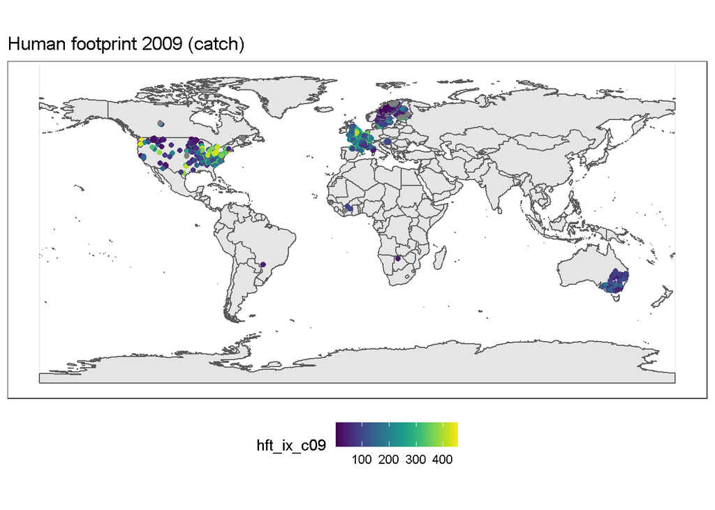

```r
ggplot(data = world) +
  geom_sf() +
  geom_sf(data = loc_hft, aes(color = hft_ix_c09), shape = 19) +
  scale_color_viridis() +
  theme(legend.position = "bottom") +
  labs(title = "Human footprint 2009 (catch)")
```

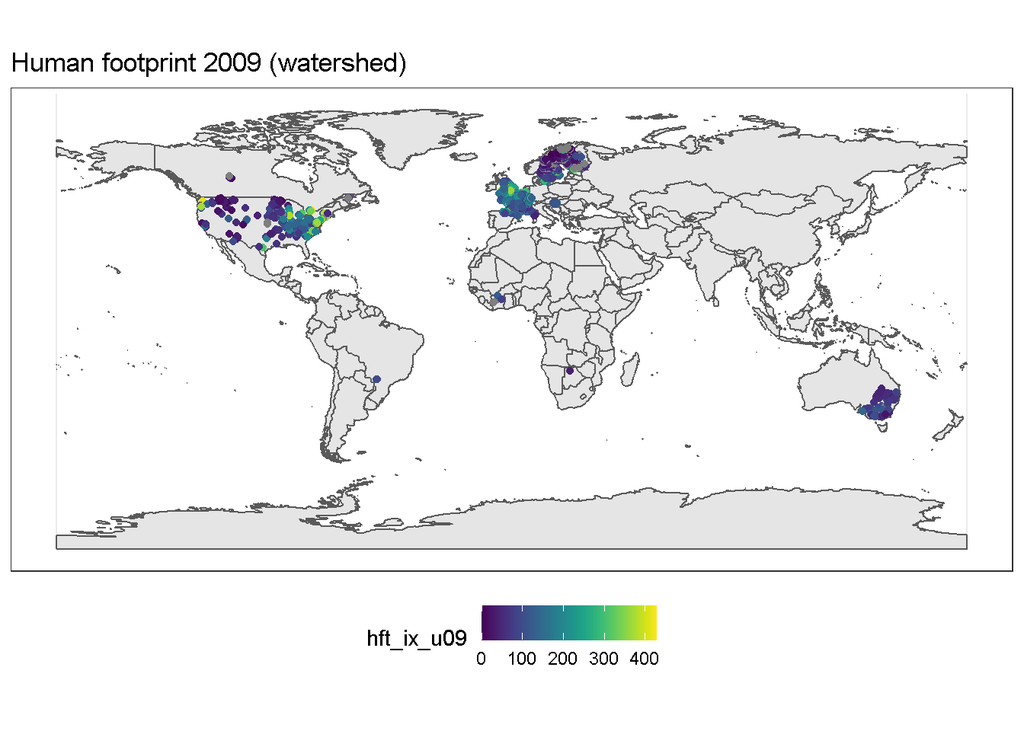

```r
ggplot(data = world) +
  geom_sf() +
  geom_sf(data = loc_hft, aes(color = hft_ix_u09), shape = 19) +
  scale_color_viridis() +
  theme(legend.position = "bottom") +
  labs(title = "Human footprint 2009 (watershed)")
```

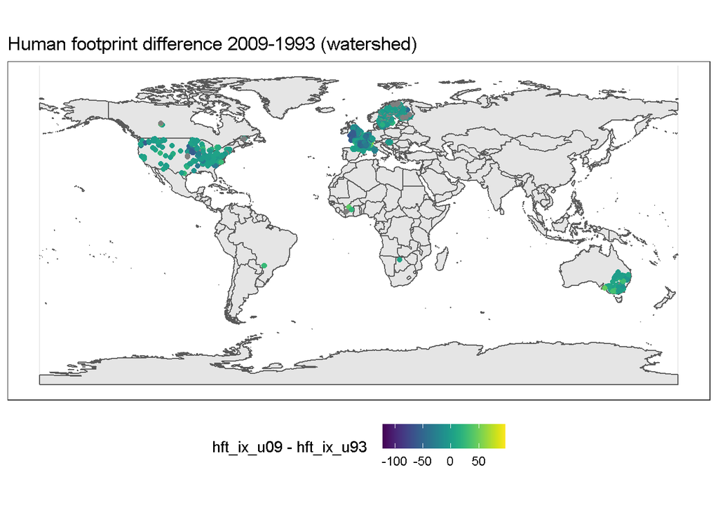

```r
ggplot(data = world) +
  geom_sf() +
  geom_sf(data = loc_hft, aes(color = hft_ix_u09 - hft_ix_u93), shape = 19) +
  scale_color_viridis() +
  theme(legend.position = "bottom") +
  labs(title = "Human footprint difference 2009-1993 (watershed)")
```

```r
pca_riv <- dudi.pca(df = scale(riv), scannf = FALSE, nf = 3)
```

- We see two main axis (as I found in France):
  - First axis related to stream size (distance from source, River area)
  - Second axis related to Temperature

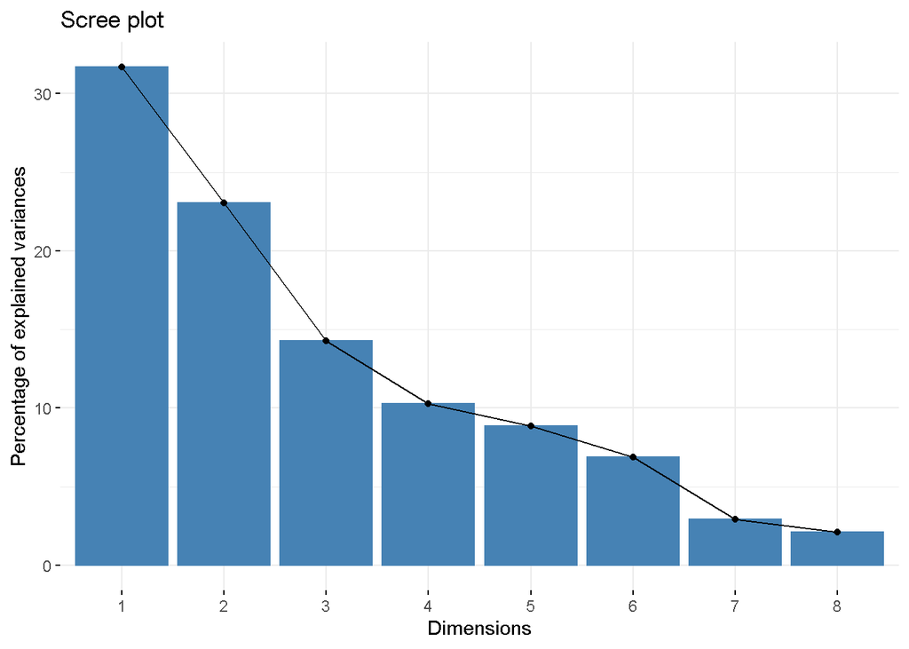

```r
fviz_eig(pca_riv)
```

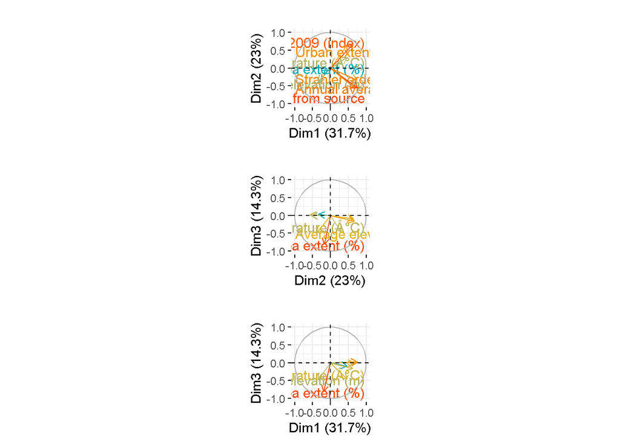

```r
p_pca <- map(list(c(1,2), c(2, 3), c(1, 3)),
  ~fviz_pca_var(pca_riv,
    axes = .x,
    col.var = "contrib", # Color by contributions to the PC
    gradient.cols = c("#00AFBB", "#E7B800", "#FC4E07"),
    repel = TRUE     # Avoid text overlapping
    ) +
  theme(legend.position = "none") + labs(title = "")
)

plot_grid(plotlist = p_pca, ncol = 1)
```

- With logged variables:

```r
logged_riv <- riv %>%
  mutate(across(c("Distance from source", "Strahler order", "Average elevation (m)",
        "Annual average of discharge (m3/s)", "Protected area extent (%)", "Urban extent (%)"),
      ~log(.x  + min(.x) + 1)))
skim(logged_riv)
```

Data summary

| Name | logged_riv |
| --- | --- |
| Number of rows | 4916 |
| Number of columns | 8 |
| _______________________ |  |
| Column type frequency: |  |
| numeric | 8 |
| ________________________ |  |
| Group variables | None |

**Variable type: numeric**

| skim_variable | n_missing | complete_rate | mean | sd | p0 | p25 | p50 | p75 | p100 | hist |
| --- | --- | --- | --- | --- | --- | --- | --- | --- | --- | --- |
| Distance from source | 0 | 1 | 3.56 | 1.02 | 1.86 | 2.82 | 3.35 | 4.04 | 7.94 | ▇▇▂▁▁ |
| Strahler order | 0 | 1 | 1.44 | 0.29 | 1.10 | 1.10 | 1.39 | 1.61 | 2.40 | ▅▇▂▁▁ |
| Average elevation (m) | 2 | 1 | -Inf | NaN | -Inf | 4.43 | 5.08 | 5.60 | 7.84 | ▁▁▇▇▁ |
| Annual average of temperature (Â°C) | 0 | 1 | 8.05 | 3.76 | -2.70 | 6.10 | 8.40 | 10.20 | 27.40 | ▂▇▇▁▁ |
| Annual average of discharge (m3/s) | 0 | 1 | 1.47 | 1.47 | 0.05 | 0.46 | 0.94 | 1.97 | 8.97 | ▇▂▁▁▁ |
| Protected area extent (%) | 0 | 1 | 1.18 | 1.65 | 0.00 | 0.00 | 0.00 | 2.08 | 4.62 | ▇▁▁▁▂ |
| Urban extent (%) | 0 | 1 | 0.79 | 1.48 | 0.00 | 0.00 | 0.00 | 0.00 | 4.62 | ▇▁▁▁▁ |
| Human footprint 2009 (index) | 0 | 1 | 169.08 | 111.71 | 2.00 | 77.00 | 142.00 | 250.00 | 456.00 | ▇▇▅▃▂ |

```r
pca_data_logged_riv <- logged_riv %>%
  filter(`Average elevation (m)` != -Inf)
pca_logged_riv <- dudi.pca(df = scale(na.omit(pca_data_logged_riv)), scannf = FALSE, nf = 3)
```

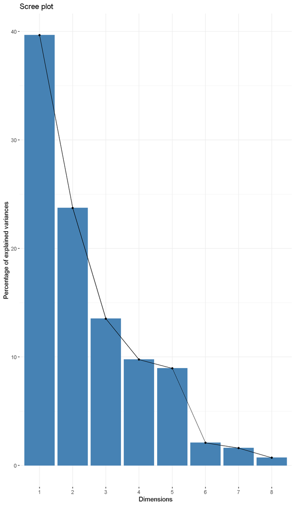

```r
fviz_eig(pca_logged_riv)
```

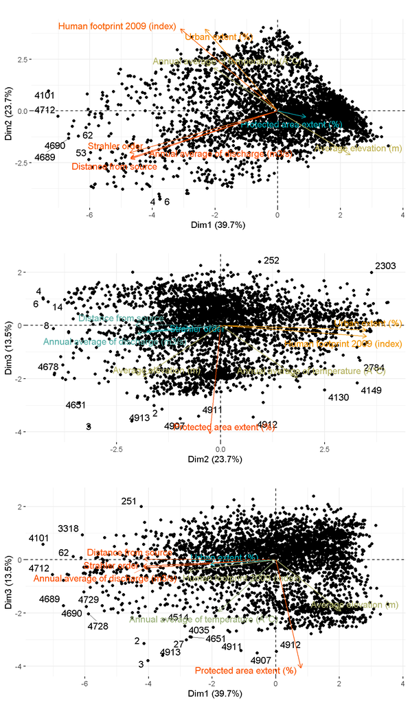

```r
p_pca_logged_riv <- map(list(c(1, 2), c(2, 3), c(1, 3)),
  ~fviz_pca_biplot(pca_logged_riv,
    axes = .x,
    col.var = "contrib", # Color by contributions to the PC
    gradient.cols = c("#00AFBB", "#E7B800", "#FC4E07"),
    repel = TRUE     # Avoid text overlapping
    ) +
  theme(legend.position = "none") + labs(title = "")
)
plot_grid(plotlist = p_pca_logged_riv, ncol = 1)
```

```r
lc_var <- c(
#  "Potential Natural Vegetation Extent (catchment)" = "pnv_pc_c01-c15",
#  "Potential Natural Vegetation Extent (watershed)" = "pnv_pc_u01-u15",
  "Forest Cover Extent (catchment)" = "for_pc_cse",
  "Forest Cover Extent (watershed)" = "for_pc_use",
  "Cropland Extent (catchment)" = "crp_pc_cse",
  "Cropland Extent (watershed)" = "crp_pc_use",
  "Pasture Extent (catchment)" = "pst_pc_cse",
  "Pasture Extent (watershed)" = "pst_pc_use",
  "Urban Extent (catchment)" = "urb_pc_cse",
  "Urban Extent (watershed)" = "urb_pc_use",
 "Population Density (catchment)" = "ppd_pk_cav",
 "Population Density (watershed)" = "ppd_pk_uav"
)
```

```r
lc_hft <- riveratlas_site %>%
  select(all_of(c(
        lc_var[str_detect(names(lc_var), "catchment")],
        get_river_atlas_significant_var()[
          str_detect(get_river_atlas_significant_var(), "hft_")
          ]
        )))
```

```r
pca_data_lc_hft <- lc_hft %>%
  st_drop_geometry()
skim(pca_data_lc_hft)
```

Data summary

| Name | pca_data_lc_hft |
| --- | --- |
| Number of rows | 4916 |
| Number of columns | 7 |
| _______________________ |  |
| Column type frequency: |  |
| numeric | 7 |
| ________________________ |  |
| Group variables | None |

**Variable type: numeric**

| skim_variable | n_missing | complete_rate | mean | sd | p0 | p25 | p50 | p75 | p100 | hist |
| --- | --- | --- | --- | --- | --- | --- | --- | --- | --- | --- |
| Forest Cover Extent (catchment) | 0 | 1 | 44.36 | 42.40 | 0 | 0.00 | 37.0 | 92.00 | 100.0 | ▇▁▁▂▆ |
| Cropland Extent (catchment) | 0 | 1 | 21.91 | 25.25 | 0 | 1.00 | 13.0 | 34.00 | 100.0 | ▇▂▁▁▁ |
| Pasture Extent (catchment) | 0 | 1 | 14.35 | 19.28 | 0 | 0.00 | 6.0 | 22.00 | 100.0 | ▇▂▁▁▁ |
| Urban Extent (catchment) | 0 | 1 | 9.28 | 22.71 | 0 | 0.00 | 0.0 | 0.00 | 100.0 | ▇▁▁▁▁ |
| Population Density (catchment) | 0 | 1 | 212.41 | 676.69 | 0 | 7.97 | 27.7 | 103.99 | 16739.2 | ▇▁▁▁▁ |
| Human footprint 1993 (index) | 0 | 1 | 182.44 | 112.87 | 2 | 85.00 | 165.5 | 268.25 | 456.0 | ▇▇▆▅▂ |
| Human footprint 2009 (index) | 0 | 1 | 169.08 | 111.71 | 2 | 77.00 | 142.0 | 250.00 | 456.0 | ▇▇▅▃▂ |

```r
pca_lc_hft <- dudi.pca(
  df = scale(na.omit(pca_data_lc_hft)),
  scannf = FALSE, nf = 3)
```

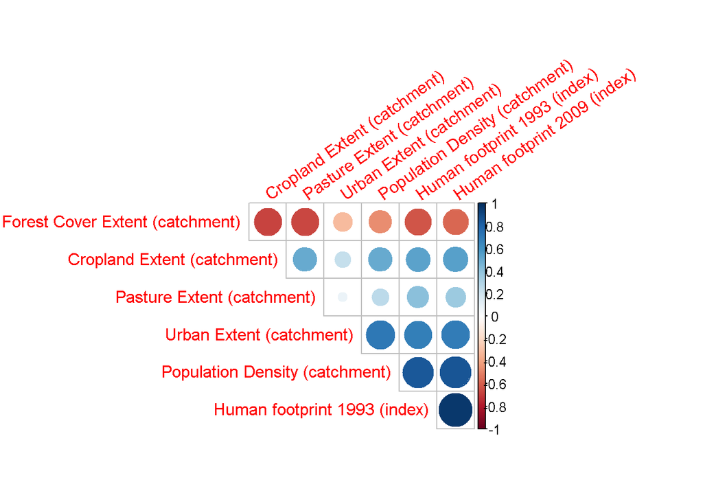

```r
corrplot::corrplot(
  cor(as.matrix(pca_data_lc_hft), method = "spearman"),
  type = "upper", tl.srt = 35, diag = FALSE)
```

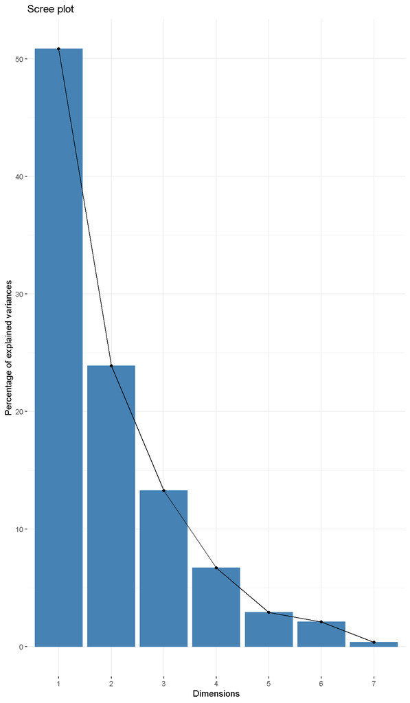

```r
fviz_eig(pca_lc_hft)
```

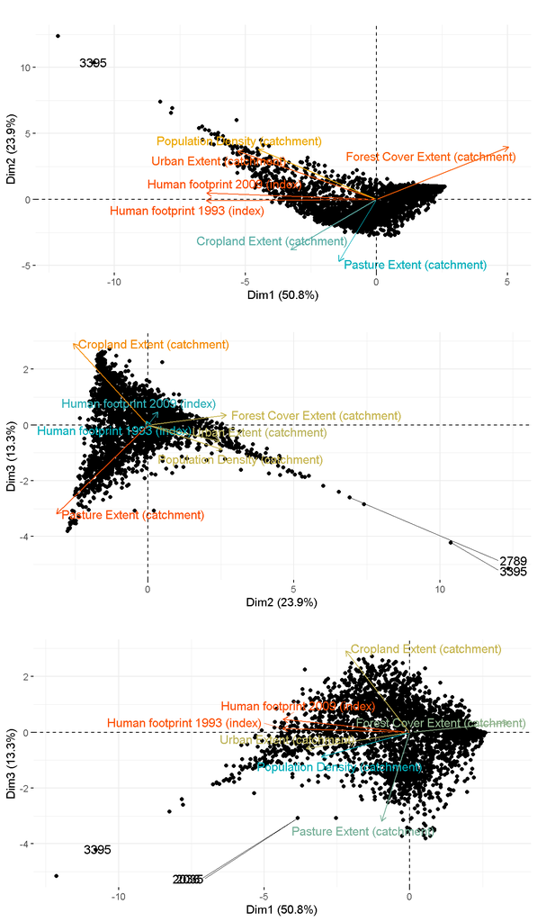

```r
p_pca_lc_hft <- map(list(c(1, 2), c(2, 3), c(1, 3)),
  ~fviz_pca_biplot(pca_lc_hft,
    axes = .x,
    col.var = "contrib", # Color by contributions to the PC
    gradient.cols = c("#00AFBB", "#E7B800", "#FC4E07"),
    repel = TRUE     # Avoid text overlapping
    ) +
  theme(legend.position = "none") + labs(title = "")
)
plot_grid(plotlist = p_pca_lc_hft, ncol = 1)
```

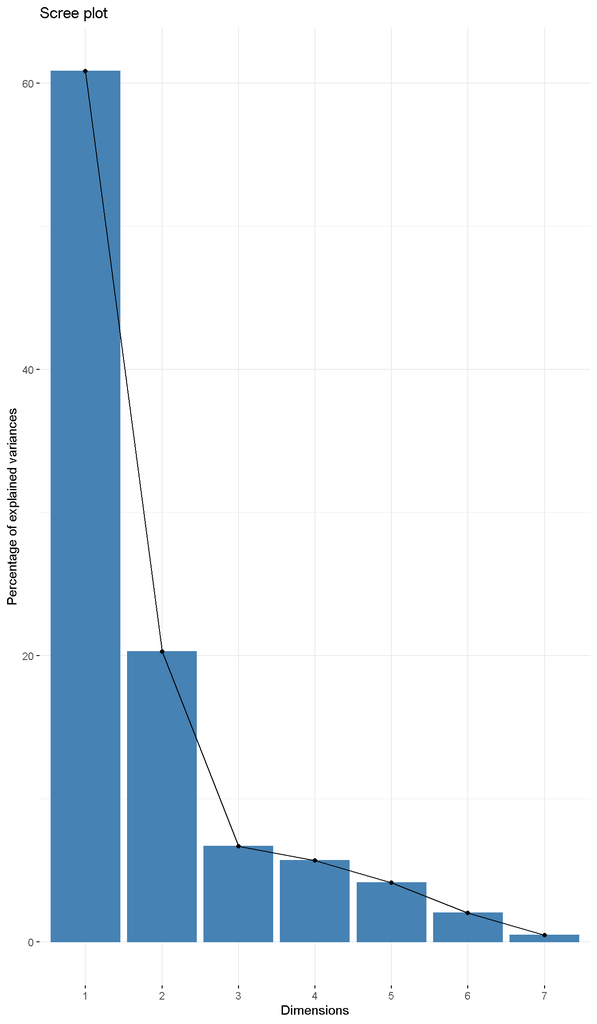

```r
pca_logged_data_lc_hft <- pca_data_lc_hft %>%
  mutate(across(where(is.numeric),
      ~log(.x  + min(.x) + 1)))

pca_logged_lc_hft <- dudi.pca(
  df = scale(na.omit(pca_logged_data_lc_hft)),
  scannf = FALSE, nf = 3
)

fviz_eig(pca_logged_lc_hft)
```

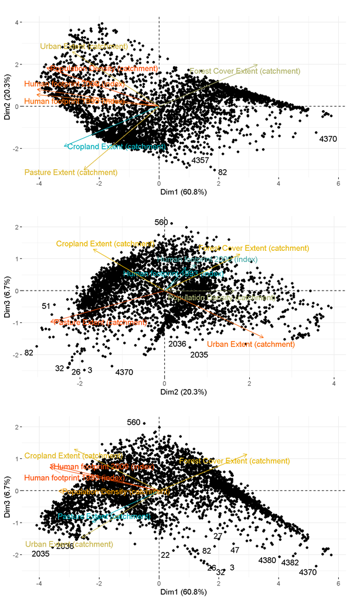

```r
p_pca_logged_lc_hft <- map(list(c(1, 2), c(2, 3), c(1, 3)),
  ~fviz_pca_biplot(pca_logged_lc_hft,
    axes = .x,
    col.var = "contrib", # Color by contributions to the PC
    gradient.cols = c("#00AFBB", "#E7B800", "#FC4E07"),
    repel = TRUE     # Avoid text overlapping
    ) +
  theme(legend.position = "none") + labs(title = "")
)
plot_grid(plotlist = p_pca_logged_lc_hft, ncol = 1)
```

```r
riv_str_var <- colnames(riveratlas_site)[
  colnames(riveratlas_site) %in%
    c("dist_up_km", "ord_stra", "dis_m3_pyr", "ele_mt_cav", "slp_dg_cav")]
summary(riveratlas_site$ele_mt_cav)
```

```
#>    Min. 1st Qu.  Median    Mean 3rd Qu.    Max.
#>      -1      84     160     234     271    2531
```

```r
logged_riv_str <- riveratlas_site %>%
  st_drop_geometry() %>%
  select(all_of(c("siteid", riv_str_var))) %>%
  mutate(across(where(is.numeric), ~log(.x + abs(min(.x)) + 1)))
```

- PCA on river structure:

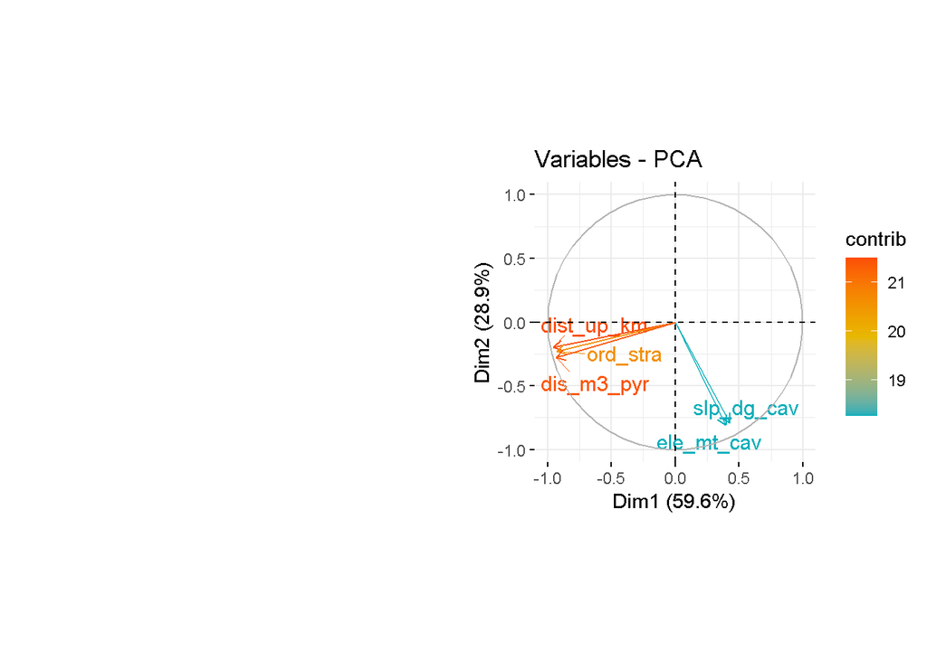

```r
tar_load(c(pca_riv_str, p_pca_riv_str))
plot_grid(plotlist = p_pca_riv_str)
```

#### Environment - Trends

```r
slp_env_for_pca <- slp_env %>%
  select(-all_of(c("siteid", "main_bas", "ecoregion", "geometry"))) %>%
  rename(get_river_atlas_significant_var())
slp_env_for_pca$geometry <- NULL

pca_slp_env <- dudi.pca(
  df = scale(na.omit(slp_env_for_pca)),
  scannf = FALSE, nf = 3)
```

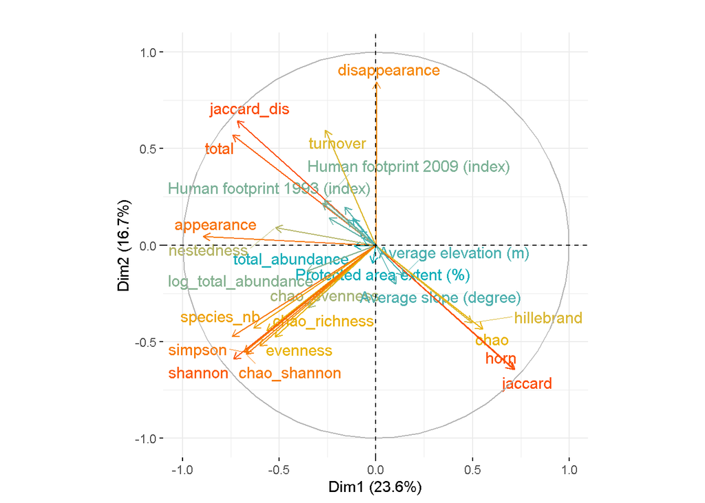

```r
p_slp_env_pca <- map(list(c(1,2), c(2, 3), c(1, 3)),

  ~fviz_pca_var(pca_slp_env,
    axes = .x,
    col.var = "contrib", # Color by contributions to the PC
    gradient.cols = c("#00AFBB", "#E7B800", "#FC4E07"),
    repel = TRUE     # Avoid text overlapping
    ) +
  theme(legend.position = "none") + labs(title = "")
)

p_slp_env_pca[[1]]
```

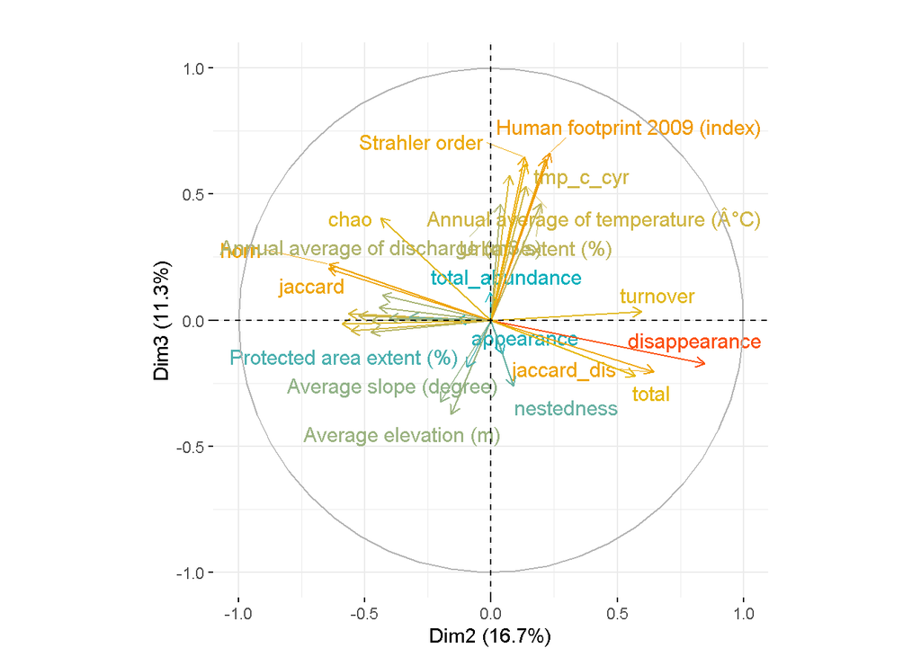

```r
p_slp_env_pca[[2]]
```

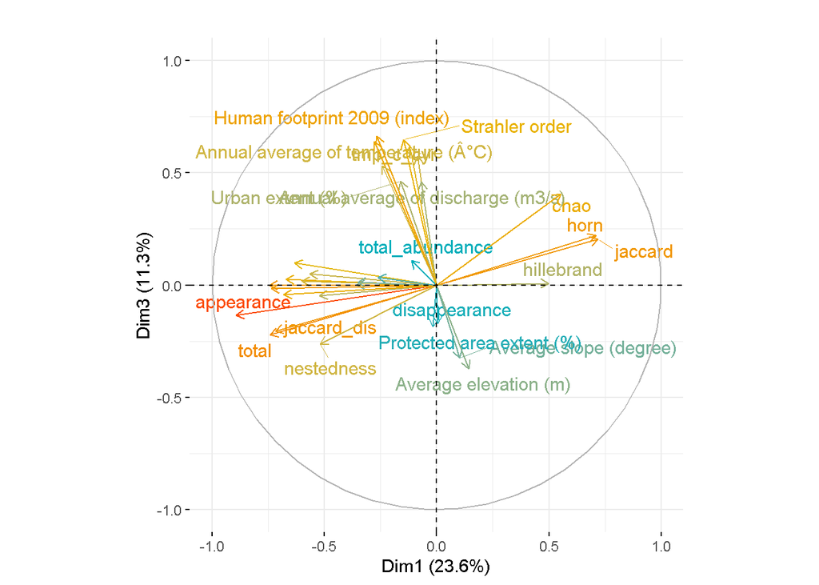

```r
p_slp_env_pca[[3]]
```

## Water temperature

```r
tar_load(c(wt_mv_avg, filtered_dataset))
wt_mv_avg  <- wt_mv_avg %>%
  ungroup()
```

```r
library(glmmTMB)
library(DHARMa)
library(ggeffects)
library(emmeans)
mod_wt_data <- wt_mv_avg  %>%
  left_join(
    filtered_dataset$location %>%
    select(siteid, ecoregion, main_bas) %>%
    mutate(main_bas = as.character(main_bas)),
    by = "siteid"
  )
```

```r
#https://stackoverflow.com/questions/66467641/partial-effect-plots-from-spamm
tar_load(mod_wt)

#vignette('troubleshooting')
diagnose(mod_wt)
```

```
#> Unusually large coefficients (|x|>10):
#>
#> theta_1+year|siteid:main_bas.3
#>                       -25.6332
#>
#> Large negative coefficients in zi (log-odds of zero-inflation),
#> dispersion, or random effects (log-standard deviations) suggest
#> unnecessary components (converging to zero on the constrained scale);
#> large negative and/or positive components in binomial or Poisson
#> conditional parameters suggest (quasi-)complete separation
#>
#>
#> Unusually large Z-statistics (|x|>5):
#>
#>   ecoregionAustralasia year:ecoregionNearctic
#>               101.6047             -1225.9363
#>
#> Large Z-statistics (estimate/std err) suggest a failure of the Wald
#> approximation - often also associated with parameters that are at or
#> near the edge of their range (e.g. random-effects standard deviations
#> approaching 0).  While the Wald p-values and standard errors listed in
#> summary() are unreliable, profile confidence intervals (see
#> ?confint.glmmTMB) and likelihood ratio test p-values derived by
#> comparing models (e.g. ?drop1) may still be OK.  (Note that the LRT is
#> conservative when the null value is on the boundary, e.g. a variance or
#> zero-inflation value of 0 (Self and Liang 1987; Stram and Lee 1994;
#> Goldman and Whelan 2000); in simple cases the p-value is approximately
#> twice as large as it should be.)
```

```r
broom.mixed::tidy(mod_wt, type = "fixed")
```

```
#> # A tibble: 17 x 8
#>    effect   component group           term  estimate std.error statistic p.value
#>    <chr>    <chr>     <chr>           <chr>    <dbl>     <dbl>     <dbl>   <dbl>
#>  1 fixed    cond      <NA>            (Int~ -1.06e+1   21.2    -0.498     0.618
#>  2 fixed    cond      <NA>            year   1.87e-2    0.0109  1.71      0.0868
#>  3 fixed    cond      <NA>            ecor~  2.67e-1   27.1     0.00984   0.992
#>  4 fixed    cond      <NA>            ecor~ -1.24e+1   21.8    -0.571     0.568
#>  5 fixed    cond      <NA>            ecor~ -2.69e+1   37.6    -0.717     0.473
#>  6 fixed    cond      <NA>            ecor~ -2.55e+1   21.2    -1.20      0.230
#>  7 fixed    cond      <NA>            year~ -4.64e-3    0.0141 -0.329     0.742
#>  8 fixed    cond      <NA>            year~ -9.18e-6    0.0113 -0.000816  0.999
#>  9 fixed    cond      <NA>            year~  1.25e-2    0.0196  0.640     0.522
#> 10 fixed    cond      <NA>            year~  4.41e-3    0.0110  0.402     0.688
#> 11 ran_pars cond      siteid:main_bas sd__~  4.10e+1   NA      NA        NA
#> 12 ran_pars cond      siteid:main_bas sd__~  2.09e-2   NA      NA        NA
#> 13 ran_pars cond      siteid:main_bas cor_~ -9.99e-1   NA      NA        NA
#> 14 ran_pars cond      main_bas        sd__~  1.99e+1   NA      NA        NA
#> 15 ran_pars cond      main_bas        sd__~  1.07e-2   NA      NA        NA
#> 16 ran_pars cond      main_bas        cor_~ -9.90e-1   NA      NA        NA
#> 17 ran_pars cond      Residual        sd__~  2.14e-1   NA      NA        NA
```

```r
#emmeans::emmeans(mod_wt, "year", type = "response")
#sim_res <- DHARMa::simulateResiduals(mod_wt)
#plot(sim_res)
```

```r
pr <- ggpredict(mod_wt, "year")
```

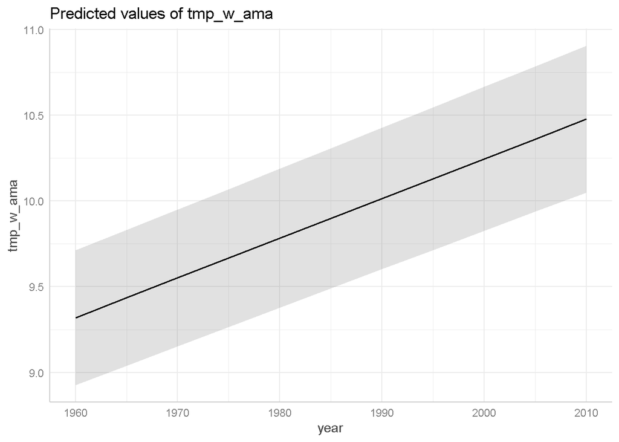

```r
plot(pr)
```

```r
# No
me <- ggpredict(mod_wt,
  terms = c("year", "ecoregion"),
  type = "random")
```

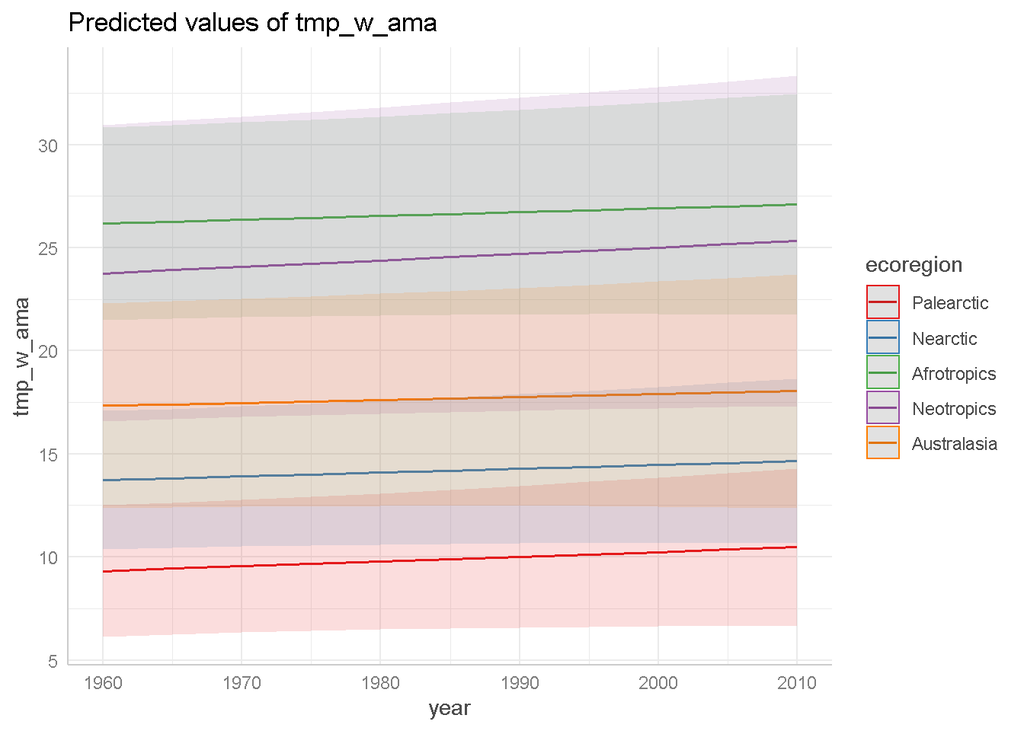

```r
plot(me)
```

```r
#
bas <- ggpredict(mod_wt,
  terms = c("year", "main_bas [sample=8]"),
  type = "random")
```

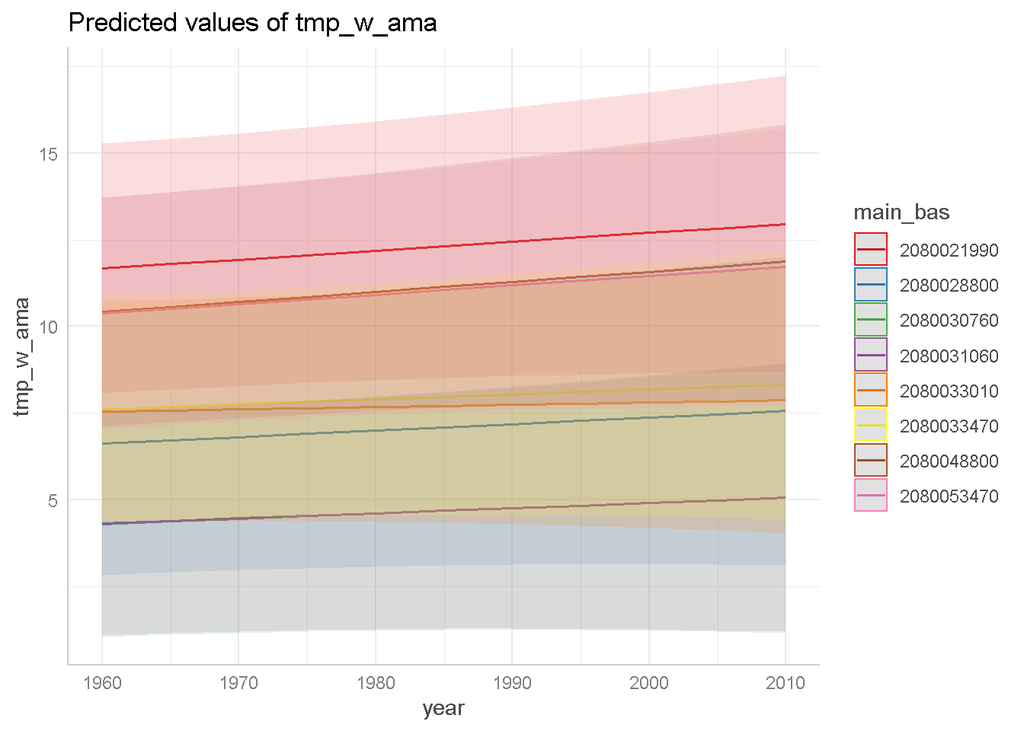

```r
plot(bas)
```

```r
coef_wt <- coef(mod_wt)
coef_site <- coef_wt$cond$`siteid:main_bas` %>%
  mutate(
    siteid = stringr::str_split(row.names(coef_wt$cond$`siteid:main_bas`), ":") %>%
  map_chr(., 1),
main_bas = stringr::str_split(row.names(coef_wt$cond$`siteid:main_bas`), ":") %>%
  map_chr(., 2)
  )

loc_wt_year_slp <- filtered_dataset$location %>%
  st_as_sf(coords = c("longitude", "latitude"),
  crs = 4326) %>%
left_join(coef_site, by = "siteid")
```

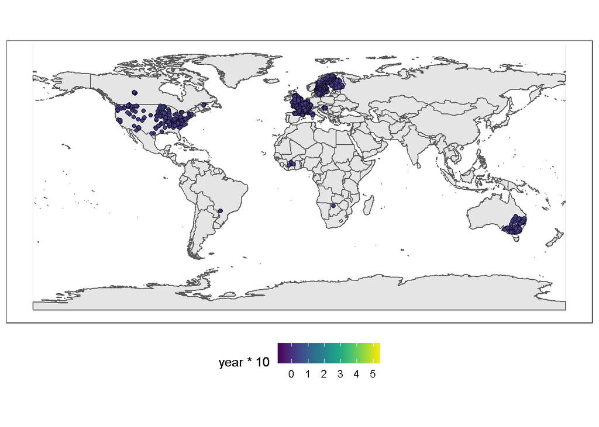

```r
ggplot(data = world) +
    geom_sf() +
    geom_sf(data = loc_wt_year_slp, aes(fill = year * 10), shape = 21) +
    scale_fill_viridis() +
    theme(legend.position = "bottom")
```

```r
coef_bas <- coef_wt$cond$`main_bas` %>%
  mutate( main_bas = row.names(coef_wt$cond$`main_bas`))
```

```r
loc_wt_year_slp_bas <- filtered_dataset$location %>%
  st_as_sf(coords = c("longitude", "latitude"), crs = 4326) %>%
  mutate(main_bas = as.character(main_bas)) %>%
  left_join(coef_bas, by = "main_bas")
```

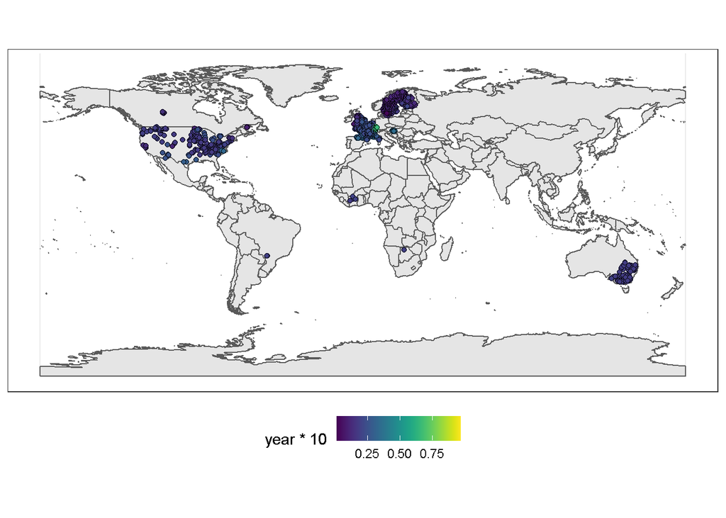

```r
ggplot(data = world) +
    geom_sf() +
    geom_sf(data = loc_wt_year_slp_bas, aes(fill = year * 10), shape = 21) +
    scale_fill_viridis() +
    theme(legend.position = "bottom")
```

```r
tar_load(analysis_dataset)
skim(analysis_dataset)
```

Data summary

| Name | analysis_dataset |
| --- | --- |
| Number of rows | 62174 |
| Number of columns | 85 |
| _______________________ |  |
| Column type frequency: |  |
| character | 11 |
| factor | 1 |
| numeric | 73 |
| ________________________ |  |
| Group variables | None |

**Variable type: character**

| skim_variable | n_missing | complete_rate | min | max | empty | n_unique | whitespace |
| --- | --- | --- | --- | --- | --- | --- | --- |
| op_id | 0 | 1.00 | 4 | 8 | 0 | 62174 | 0 |
| siteid | 0 | 1.00 | 2 | 6 | 0 | 5516 | 0 |
| protocol | 0 | 1.00 | 7 | 29 | 0 | 15 | 0 |
| protocol_detail | 0 | 1.00 | 7 | 29 | 0 | 14 | 0 |
| unitbiomass | 45609 | 0.27 | 1 | 9 | 0 | 4 | 0 |
| unitabundance | 0 | 1.00 | 4 | 12 | 0 | 4 | 0 |
| province | 2384 | 0.96 | 3 | 28 | 0 | 632 | 0 |
| waterbody | 2384 | 0.96 | 2 | 31 | 0 | 2559 | 0 |
| country | 251 | 1.00 | 3 | 3 | 0 | 14 | 0 |
| region | 2384 | 0.96 | 3 | 26 | 0 | 109 | 0 |
| ecoregion | 251 | 1.00 | 8 | 11 | 0 | 5 | 0 |

**Variable type: factor**

| skim_variable | n_missing | complete_rate | ordered | n_unique | top_counts |
| --- | --- | --- | --- | --- | --- |
| main_bas | 251 | 1 | FALSE | 308 | 708: 2941, 208: 2648, 208: 2304, 208: 1636 |

**Variable type: numeric**

| skim_variable | n_missing | complete_rate | mean | sd | p0 | p25 | p50 | p75 | p100 | hist |
| --- | --- | --- | --- | --- | --- | --- | --- | --- | --- | --- |
| species_nb | 0 | 1.00 | 5.60 | 5.92 | 1.00 | 2.00 | 3.00 | 7.00 | 72.00 | ▇▁▁▁▁ |
| total_abundance | 0 | 1.00 | 228.03 | 1125.99 | 0.01 | 19.10 | 56.00 | 181.00 | 109088.00 | ▇▁▁▁▁ |
| log_total_abundance | 0 | 1.00 | 4.04 | 1.71 | -4.61 | 2.95 | 4.03 | 5.20 | 11.60 | ▁▁▇▃▁ |
| log_species_nb | 0 | 1.00 | 1.33 | 0.87 | 0.00 | 0.69 | 1.10 | 1.95 | 4.28 | ▇▇▅▂▁ |
| year | 0 | 1.00 | 2004.92 | 8.56 | 1955.00 | 1999.00 | 2006.00 | 2012.00 | 2019.00 | ▁▁▂▇▇ |
| latitude | 251 | 1.00 | 53.02 | 12.30 | -37.47 | 48.07 | 55.81 | 59.42 | 68.48 | ▁▁▁▂▇ |
| longitude | 251 | 1.00 | 1.37 | 34.09 | -123.07 | -1.25 | 11.91 | 15.38 | 151.92 | ▁▁▇▁▁ |
| chao_richness | 0 | 1.00 | 5.12 | 5.45 | 1.00 | 1.94 | 3.14 | 6.44 | 85.71 | ▇▁▁▁▁ |
| chao_shannon | 0 | 1.00 | 2.79 | 2.59 | 0.00 | 1.35 | 2.13 | 3.63 | 33.63 | ▇▁▁▁▁ |
| chao_simpson | 0 | 1.00 | 2.23 | 1.92 | 0.00 | 1.20 | 1.79 | 2.89 | 40.00 | ▇▁▁▁▁ |
| chao_evenness | 0 | 1.00 | 1.93 | 1.54 | 0.00 | 1.47 | 2.06 | 2.47 | 38.25 | ▇▁▁▁▁ |
| hillebrand | 0 | 1.00 | 0.68 | 0.33 | 0.00 | 0.42 | 0.79 | 0.99 | 1.00 | ▂▂▂▂▇ |
| total | 0 | 1.00 | 0.24 | 0.20 | 0.00 | 0.00 | 0.25 | 0.38 | 1.00 | ▇▆▃▁▁ |
| appearance | 0 | 1.00 | 0.14 | 0.16 | 0.00 | 0.00 | 0.10 | 0.24 | 0.92 | ▇▃▁▁▁ |
| disappearance | 0 | 1.00 | 0.11 | 0.14 | 0.00 | 0.00 | 0.00 | 0.17 | 0.86 | ▇▂▁▁▁ |
| jaccard | 0 | 1.00 | 0.65 | 0.27 | 0.00 | 0.50 | 0.67 | 1.00 | 1.00 | ▁▃▇▆▇ |
| horn | 0 | 1.00 | 0.76 | 0.22 | 0.00 | 0.67 | 0.80 | 1.00 | 1.00 | ▁▁▂▅▇ |
| chao | 0 | 1.00 | 0.86 | 0.26 | 0.00 | 0.83 | 1.00 | 1.00 | 1.00 | ▁▁▁▁▇ |
| total_abundance_int | 0 | 1.00 | 227.72 | 1126.03 | 0.00 | 19.00 | 56.00 | 181.00 | 109088.00 | ▇▁▁▁▁ |
| shannon | 0 | 1.00 | 0.86 | 0.65 | 0.00 | 0.34 | 0.76 | 1.29 | 3.54 | ▇▆▃▁▁ |
| simpson | 0 | 1.00 | 0.42 | 0.28 | 0.00 | 0.17 | 0.48 | 0.66 | 0.96 | ▇▅▇▇▃ |
| inv_simpson | 0 | 1.00 | 2.39 | 1.72 | 1.00 | 1.21 | 1.91 | 2.90 | 23.24 | ▇▁▁▁▁ |
| evenness | 0 | 1.00 | 0.54 | 0.30 | 0.00 | 0.33 | 0.63 | 0.77 | 1.00 | ▅▂▅▇▅ |
| jaccard_dis | 0 | 1.00 | 0.35 | 0.27 | 0.00 | 0.00 | 0.33 | 0.50 | 1.00 | ▇▆▆▃▁ |
| nestedness | 0 | 1.00 | 0.19 | 0.22 | 0.00 | 0.00 | 0.10 | 0.33 | 0.96 | ▇▂▂▁▁ |
| turnover | 0 | 1.00 | 0.16 | 0.25 | 0.00 | 0.00 | 0.00 | 0.33 | 1.00 | ▇▂▁▁▁ |
| dist_up_km | 7548 | 0.88 | 80.14 | 194.24 | 2.70 | 13.10 | 25.40 | 58.20 | 2798.30 | ▇▁▁▁▁ |
| ord_stra | 7548 | 0.88 | 2.48 | 1.46 | 1.00 | 1.00 | 2.00 | 3.00 | 9.00 | ▇▅▁▁▁ |
| dis_m3_pyr | 7548 | 0.88 | 56.22 | 336.69 | 0.03 | 0.55 | 1.61 | 7.30 | 7830.69 | ▇▁▁▁▁ |
| ele_mt_cav | 7548 | 0.88 | 228.87 | 260.96 | -1.00 | 84.00 | 158.00 | 265.00 | 2531.00 | ▇▁▁▁▁ |
| slp_dg_cav | 7548 | 0.88 | 40.56 | 37.92 | 0.00 | 19.00 | 32.00 | 46.00 | 362.00 | ▇▁▁▁▁ |
| tmp_dc_cyr | 7548 | 0.88 | 76.18 | 39.01 | -27.00 | 57.00 | 77.00 | 101.00 | 274.00 | ▃▇▆▁▁ |
| pac_pc_cse | 7548 | 0.88 | 13.75 | 29.29 | 0.00 | 0.00 | 0.00 | 6.00 | 100.00 | ▇▁▁▁▁ |
| urb_pc_cse | 7548 | 0.88 | 7.74 | 20.72 | 0.00 | 0.00 | 0.00 | 0.00 | 100.00 | ▇▁▁▁▁ |
| hft_ix_c93 | 7548 | 0.88 | 170.95 | 108.72 | 2.00 | 80.00 | 147.00 | 248.00 | 456.00 | ▇▇▅▃▂ |
| hft_ix_c09 | 7548 | 0.88 | 158.25 | 107.17 | 2.00 | 72.00 | 132.00 | 226.00 | 456.00 | ▇▇▃▂▁ |
| riv_str_rc1 | 7548 | 0.88 | 0.05 | 1.06 | -1.51 | -0.79 | -0.22 | 0.57 | 4.07 | ▇▇▃▁▁ |
| riv_str_rc2 | 7548 | 0.88 | 0.01 | 0.96 | -4.88 | -0.53 | -0.03 | 0.56 | 3.05 | ▁▁▇▇▁ |
| first_year | 0 | 1.00 | 1993.70 | 8.17 | 1955.00 | 1989.00 | 1994.00 | 2000.00 | 2010.00 | ▁▁▃▇▅ |
| last_year | 0 | 1.00 | 2015.22 | 4.59 | 1980.00 | 2015.00 | 2017.00 | 2018.00 | 2019.00 | ▁▁▁▁▇ |
| span | 0 | 1.00 | 22.52 | 8.43 | 10.00 | 16.00 | 22.00 | 29.00 | 64.00 | ▇▇▂▁▁ |
| chao_richness_tps | 0 | 1.00 | 0.24 | 0.99 | -0.97 | -0.14 | 0.00 | 0.35 | 25.00 | ▇▁▁▁▁ |
| species_nb_tps | 0 | 1.00 | 0.25 | 1.10 | -0.96 | -0.07 | 0.00 | 0.33 | 23.00 | ▇▁▁▁▁ |
| total_abundance_tps | 0 | 1.00 | 3.45 | 35.24 | -1.00 | -0.38 | 0.04 | 1.35 | 3051.81 | ▇▁▁▁▁ |
| jaccard_scaled | 0 | 1.00 | 0.65 | 0.27 | 0.00 | 0.50 | 0.67 | 1.00 | 1.00 | ▁▃▇▆▇ |
| jaccard_dis_scaled | 0 | 1.00 | 0.35 | 0.27 | 0.00 | 0.00 | 0.33 | 0.50 | 1.00 | ▇▆▆▃▁ |
| nestedness_scaled | 0 | 1.00 | 0.19 | 0.22 | 0.00 | 0.00 | 0.10 | 0.33 | 0.96 | ▇▂▂▁▁ |
| turnover_scaled | 0 | 1.00 | 0.16 | 0.25 | 0.00 | 0.00 | 0.00 | 0.33 | 1.00 | ▇▂▁▁▁ |
| hillebrand_scaled | 0 | 1.00 | 0.68 | 0.33 | 0.00 | 0.42 | 0.79 | 0.99 | 1.00 | ▂▂▂▂▇ |
| hillebrand_dis | 0 | 1.00 | 0.32 | 0.33 | 0.00 | 0.01 | 0.21 | 0.58 | 1.00 | ▇▂▂▂▂ |
| hillebrand_dis_scaled | 0 | 1.00 | 0.32 | 0.33 | 0.00 | 0.01 | 0.21 | 0.58 | 1.00 | ▇▂▂▂▂ |
| appearance_scaled | 0 | 1.00 | 0.14 | 0.16 | 0.00 | 0.00 | 0.10 | 0.24 | 0.92 | ▇▃▁▁▁ |
| disappearance_scaled | 0 | 1.00 | 0.11 | 0.14 | 0.00 | 0.00 | 0.00 | 0.18 | 0.86 | ▇▂▁▁▁ |
| evenness_scaled | 0 | 1.00 | 0.54 | 0.30 | 0.00 | 0.33 | 0.63 | 0.77 | 1.00 | ▅▂▅▇▅ |
| log_chao_richness | 0 | 1.00 | 1.24 | 0.86 | 0.00 | 0.66 | 1.14 | 1.86 | 4.45 | ▇▇▅▁▁ |
| chao_richness_tps_scaled | 0 | 1.00 | 0.24 | 0.99 | -0.97 | -0.14 | 0.00 | 0.35 | 25.00 | ▇▁▁▁▁ |
| species_nb_tps_scaled | 0 | 1.00 | 0.25 | 1.10 | -0.96 | -0.07 | 0.00 | 0.33 | 23.00 | ▇▁▁▁▁ |
| scaled_dist_up_km | 7548 | 0.88 | 0.00 | 1.00 | -0.40 | -0.35 | -0.28 | -0.11 | 13.99 | ▇▁▁▁▁ |
| log_dist_up_km | 7548 | 0.88 | 3.44 | 1.18 | 0.99 | 2.57 | 3.23 | 4.06 | 7.94 | ▃▇▃▁▁ |
| scaled_tmp_dc_cyr | 7548 | 0.88 | 0.00 | 1.00 | -2.65 | -0.49 | 0.02 | 0.64 | 5.07 | ▃▇▆▁▁ |
| tmp_c_cyr | 7548 | 0.88 | 7.62 | 3.90 | -2.70 | 5.70 | 7.70 | 10.10 | 27.40 | ▃▇▆▁▁ |
| scaled_tmp_c_cyr | 7548 | 0.88 | 0.00 | 1.00 | -2.65 | -0.49 | 0.02 | 0.64 | 5.07 | ▃▇▆▁▁ |
| hft_ix_c9309_percent | 7548 | 0.88 | -6.73 | 33.96 | -76.92 | -17.81 | -4.55 | 0.00 | 1709.09 | ▇▁▁▁▁ |
| log_hft_ix_c9309_percent | 7548 | 0.88 | -6.73 | 33.96 | -76.92 | -17.81 | -4.55 | 0.00 | 1709.09 | ▇▁▁▁▁ |
| hft_ix_c9309_ratio | 7548 | 0.88 | 0.93 | 0.34 | 0.23 | 0.82 | 0.95 | 1.00 | 18.09 | ▇▁▁▁▁ |
| hft_ix_c9309_log_ratio | 7548 | 0.88 | -0.10 | 0.22 | -1.47 | -0.20 | -0.05 | 0.00 | 2.90 | ▁▇▁▁▁ |
| hft_ix_c9309_diff | 7548 | 0.88 | -12.70 | 27.48 | -122.00 | -26.00 | -6.00 | 0.00 | 188.00 | ▁▇▂▁▁ |
| hft_ix_c9309_diff_scaled | 7548 | 0.88 | 0.00 | 1.00 | -3.98 | -0.48 | 0.24 | 0.46 | 7.30 | ▁▇▂▁▁ |
| hft_c9309_scaled_no_center | 7548 | 0.88 | -0.42 | 0.91 | -4.03 | -0.86 | -0.20 | 0.00 | 6.21 | ▁▇▂▁▁ |
| one | 0 | 1.00 | 1.00 | 0.00 | 1.00 | 1.00 | 1.00 | 1.00 | 1.00 | ▁▁▇▁▁ |
| year_nb | 0 | 1.00 | 11.22 | 8.66 | 0.00 | 4.00 | 10.00 | 17.00 | 63.00 | ▇▅▁▁▁ |
| log1_year_nb | 0 | 1.00 | 2.16 | 0.96 | 0.00 | 1.61 | 2.40 | 2.89 | 4.16 | ▃▃▇▇▁ |
| total_abundance_scaled | 0 | 1.00 | 0.00 | 1.00 | -1.13 | -0.14 | -0.09 | 0.02 | 123.65 | ▇▁▁▁▁ |

## Reproducibility

**Reproducibility receipt**

```r
## datetime
Sys.time()
```

```
#> [1] "2022-03-11 17:27:55 CST"
```

```r
## repository
if(requireNamespace('git2r', quietly = TRUE)) {
  git2r::repository()
} else {
  c(
    system2("git", args = c("log", "--name-status", "-1"), stdout = TRUE),
    system2("git", args = c("remote", "-v"), stdout = TRUE)
  )
}
```

```
#> Local:    main L:/alain/RivFishTimeBiodiversityFacets
#> Remote:   main @ origin (https://github.com/alaindanet/RivFishTimeBiodiversityFacets.git)
#> Head:     [0ca6017] 2022-03-05: change human footprint by scale without centering to facilitate interpretation.
```